# Quais Fatores Mais Causam Atritos no Ambiente de Trabalho que pode levar o desligamento do colaborador?

Diego

02/04/2021

#### Neste projeto nosso objetivo é analisar uma série de atributos de colaboradores de uma empresa e identificar quais atributos são mais relevantes para gerar atritos entre os colaboradores, sendo um dos motivos da pessoa desligar da empresa e então apresentaremos nossas conclusões aos tomadores de decisão.

**A fonte de dados foi extraido na empresa IBMG, são dados reais, porém não são dos funcionários da IBM**

**Configurando o diretório de trabalho**

```r
setwd("C:/FCD/Business_Analytics/Cap08")
```

**Importar as bibiotecas**

```r
library(caret)
```

```r
library(ggplot2)
library(gridExtra)
library(data.table)
library(car)
library(caTools)
library(corrplot)
library(rpart)
library(rpart.plot)
```

**Carregando o dataset**

```r
dados_rh <- fread('dados/dataset.csv')
```

**Verificando a dimensão do dataset**

```r
dim(dados_rh)
```

```
## [1] 23058    30
```

**Visualizar as primeiras linhas**

```r
head(dados_rh, 5)
```

```
##    Age             Attrition BusinessTravel      Department DistanceFromHome
## 1:  41 Voluntary Resignation  Travel_Rarely           Sales                1
## 2:  37 Voluntary Resignation  Travel_Rarely Human Resources                6
## 3:  41 Voluntary Resignation  Travel_Rarely           Sales                1
## 4:  37 Voluntary Resignation  Travel_Rarely Human Resources                6
## 5:  37 Voluntary Resignation  Travel_Rarely Human Resources                6
##    Education  EducationField EnvironmentSatisfaction Gender JobInvolvement
## 1:         2   Life Sciences                       2 Female              3
## 2:         4 Human Resources                       1 Female              3
## 3:         2   Life Sciences                       2 Female              3
## 4:         4       Marketing                       1 Female              3
## 5:         4 Human Resources                       1 Female              3
##    JobLevel         JobRole JobSatisfaction MaritalStatus MonthlyIncome
## 1:        2 Sales Executive               4        Single          5993
## 2:        2 Sales Executive               4        Single          5993
```

[output cut: 33 more lines]

**Verificar o tipo dos dados**

```r
str(dados_rh)
```

```
## Classes 'data.table' and 'data.frame':   23058 obs. of  30 variables:
##  $ Age                     : int  41 37 41 37 37 37 41 41 41 41 ...
##  $ Attrition               : chr  "Voluntary Resignation" "Voluntary Resignation" "Voluntary Resignation" "Voluntary Resignation" ...
##  $ BusinessTravel          : chr  "Travel_Rarely" "Travel_Rarely" "Travel_Rarely" "Travel_Rarely" ...
##  $ Department              : chr  "Sales" "Human Resources" "Sales" "Human Resources" ...
##  $ DistanceFromHome        : int  1 6 1 6 6 6 1 1 1 1 ...
##  $ Education               : int  2 4 2 4 4 4 2 2 2 2 ...
##  $ EducationField          : chr  "Life Sciences" "Human Resources" "Life Sciences" "Marketing" ...
##  $ EnvironmentSatisfaction : int  2 1 2 1 1 1 2 2 2 4 ...
##  $ Gender                  : chr  "Female" "Female" "Female" "Female" ...
##  $ JobInvolvement          : int  3 3 3 3 3 3 3 3 3 3 ...
##  $ JobLevel                : int  2 2 2 2 2 2 2 2 2 4 ...
##  $ JobRole                 : chr  "Sales Executive" "Sales Executive" "Sales Executive" "Sales Executive" ...
##  $ JobSatisfaction         : int  4 4 4 4 4 4 4 4 4 3 ...
##  $ MaritalStatus           : chr  "Single" "Single" "Single" "Single" ...
```

[output cut: 17 more lines]

**Resumo do dataset**

```r
summary(dados_rh)
```

```
##       Age         Attrition         BusinessTravel      Department
##  Min.   :18.00   Length:23058       Length:23058       Length:23058
##  1st Qu.:30.00   Class :character   Class :character   Class :character
##  Median :36.00   Mode  :character   Mode  :character   Mode  :character
##  Mean   :37.04
##  3rd Qu.:43.00
##  Max.   :60.00
##  DistanceFromHome   Education     EducationField     EnvironmentSatisfaction
##  Min.   : 1.000   Min.   :1.000   Length:23058       Min.   :1.00
##  1st Qu.: 2.000   1st Qu.:2.000   Class :character   1st Qu.:2.00
##  Median : 7.000   Median :3.000   Mode  :character   Median :3.00
##  Mean   : 9.215   Mean   :2.915                      Mean   :2.72
##  3rd Qu.:14.000   3rd Qu.:4.000                      3rd Qu.:4.00
##  Max.   :29.000   Max.   :5.000                      Max.   :4.00
##     Gender          JobInvolvement    JobLevel       JobRole
##  Length:23058       Min.   :1.00   Min.   :1.000   Length:23058
##  Class :character   1st Qu.:2.00   1st Qu.:1.000   Class :character
##  Mode  :character   Median :3.00   Median :2.000   Mode  :character
##                     Mean   :2.73   Mean   :2.044
##                     3rd Qu.:3.00   3rd Qu.:3.000
##                     Max.   :4.00   Max.   :5.000
##  JobSatisfaction MaritalStatus      MonthlyIncome   NumCompaniesWorked
##  Min.   :1.000   Length:23058       Min.   : 1009   Min.   :0.000
##  1st Qu.:2.000   Class :character   1st Qu.: 2900   1st Qu.:1.000
##  Median :3.000   Mode  :character   Median : 4898   Median :2.000
##  Mean   :2.725                      Mean   : 6416   Mean   :2.691
##  3rd Qu.:4.000                      3rd Qu.: 8120   3rd Qu.:4.000
##  Max.   :4.000                      Max.   :19999   Max.   :9.000
##    OverTime         PercentSalaryHike PerformanceRating
##  Length:23058       Min.   :11.00     Min.   :3.000
##  Class :character   1st Qu.:12.00     1st Qu.:3.000
##  Mode  :character   Median :14.00     Median :3.000
##                     Mean   :15.22     Mean   :3.155
##                     3rd Qu.:18.00     3rd Qu.:3.000
##                     Max.   :25.00     Max.   :4.000
##  RelationshipSatisfaction StockOptionLevel TotalWorkingYears
##  Min.   :1.000            Min.   :0.0000   Min.   : 0.00
##  1st Qu.:2.000            1st Qu.:0.0000   1st Qu.: 6.00
##  Median :3.000            Median :1.0000   Median :10.00
##  Mean   :2.713            Mean   :0.7944   Mean   :11.07
```

[output cut: 8 more lines]

```
##  Max.   :6.000         Max.   :4.000   Max.   :40.00   Max.   :18.000
##  YearsSinceLastPromotion YearsWithCurrManager Employee Source
##  Min.   : 0.000          Min.   : 0.000       Length:23058
##  1st Qu.: 0.000          1st Qu.: 2.000       Class :character
##  Median : 1.000          Median : 3.000       Mode  :character
##  Mean   : 2.164          Mean   : 4.091
##  3rd Qu.: 3.000          3rd Qu.: 7.000
##  Max.   :15.000          Max.   :17.000
##  AgeStartedWorking
##  Min.   : 0.00
##  1st Qu.:20.00
##  Median :25.00
##  Mean   :25.96
##  3rd Qu.:31.00
##  Max.   :60.00
```

**Realizar a limpeza e Transformação**

**Transformando variáveis categóricas para o tipo fator**

```r
dados_rh$Attrition                <- as.factor(dados_rh$Attrition)
dados_rh$BusinessTravel           <- as.factor(dados_rh$BusinessTravel)
dados_rh$Department               <- as.factor(dados_rh$Department)
dados_rh$Education                <- as.factor(dados_rh$Education)
dados_rh$EducationField           <- as.factor(dados_rh$EducationField)
dados_rh$'Employee Source'        <- as.factor(dados_rh$'Employee Source')
dados_rh$EnvironmentSatisfaction  <- as.factor(dados_rh$EnvironmentSatisfaction)
dados_rh$Gender                   <- as.factor(dados_rh$Gender)
dados_rh$JobInvolvement           <- as.factor(dados_rh$JobInvolvement)
dados_rh$JobLevel                 <- as.factor(dados_rh$JobLevel)
dados_rh$JobRole                  <- as.factor(dados_rh$JobRole)
dados_rh$JobSatisfaction          <- as.factor(dados_rh$JobSatisfaction)
dados_rh$MaritalStatus            <- as.factor(dados_rh$MaritalStatus)
dados_rh$OverTime                 <- as.factor(dados_rh$OverTime)
dados_rh$PerformanceRating        <- as.factor(dados_rh$PerformanceRating)
dados_rh$RelationshipSatisfaction <- as.factor(dados_rh$RelationshipSatisfaction)
dados_rh$StockOptionLevel         <- as.factor(dados_rh$StockOptionLevel)
dados_rh$WorkLifeBalance          <- as.factor(dados_rh$WorkLifeBalance)
```

**Verificar os tipos de dados**

```r
str(dados_rh)
```

```
## Classes 'data.table' and 'data.frame':   23058 obs. of  30 variables:
##  $ Age                     : int  41 37 41 37 37 37 41 41 41 41 ...
##  $ Attrition               : Factor w/ 3 levels "Current employee",..: 3 3 3 3 3 3 3 3 3 3 ...
##  $ BusinessTravel          : Factor w/ 3 levels "Non-Travel","Travel_Frequently",..: 3 3 3 3 3 3 3 3 3 3 ...
##  $ Department              : Factor w/ 3 levels "Human Resources",..: 3 1 3 1 1 1 3 3 3 3 ...
##  $ DistanceFromHome        : int  1 6 1 6 6 6 1 1 1 1 ...
##  $ Education               : Factor w/ 5 levels "1","2","3","4",..: 2 4 2 4 4 4 2 2 2 2 ...
##  $ EducationField          : Factor w/ 6 levels "Human Resources",..: 2 1 2 3 1 3 2 2 2 2 ...
##  $ EnvironmentSatisfaction : Factor w/ 4 levels "1","2","3","4": 2 1 2 1 1 1 2 2 2 4 ...
##  $ Gender                  : Factor w/ 2 levels "Female","Male": 1 1 1 1 1 1 1 1 1 1 ...
##  $ JobInvolvement          : Factor w/ 4 levels "1","2","3","4": 3 3 3 3 3 3 3 3 3 3 ...
##  $ JobLevel                : Factor w/ 5 levels "1","2","3","4",..: 2 2 2 2 2 2 2 2 2 4 ...
##  $ JobRole                 : Factor w/ 9 levels "Healthcare Representative",..: 8 8 8 8 8 8 8 8 8 4 ...
##  $ JobSatisfaction         : Factor w/ 4 levels "1","2","3","4": 4 4 4 4 4 4 4 4 4 3 ...
##  $ MaritalStatus           : Factor w/ 3 levels "Divorced","Married",..: 3 3 3 3 3 3 3 3 3 1 ...
```

[output cut: 17 more lines]

**Transformando variáveis numéricas para o tipo inteiro**

```r
dados_rh$DistanceFromHome  <- as.integer(dados_rh$DistanceFromHome)
dados_rh$MonthlyIncome     <- as.integer(dados_rh$MonthlyIncome)
dados_rh$PercentSalaryHike <- as.integer(dados_rh$PercentSalaryHike)
```

**Drop dos níveis de fatores com 0 count e visualizando características dos dados**

```r
dados <- droplevels(dados_rh)
str(dados_rh)
```

```
## Classes 'data.table' and 'data.frame':   23058 obs. of  30 variables:
##  $ Age                     : int  41 37 41 37 37 37 41 41 41 41 ...
##  $ Attrition               : Factor w/ 3 levels "Current employee",..: 3 3 3 3 3 3 3 3 3 3 ...
##  $ BusinessTravel          : Factor w/ 3 levels "Non-Travel","Travel_Frequently",..: 3 3 3 3 3 3 3 3 3 3 ...
##  $ Department              : Factor w/ 3 levels "Human Resources",..: 3 1 3 1 1 1 3 3 3 3 ...
##  $ DistanceFromHome        : int  1 6 1 6 6 6 1 1 1 1 ...
##  $ Education               : Factor w/ 5 levels "1","2","3","4",..: 2 4 2 4 4 4 2 2 2 2 ...
##  $ EducationField          : Factor w/ 6 levels "Human Resources",..: 2 1 2 3 1 3 2 2 2 2 ...
##  $ EnvironmentSatisfaction : Factor w/ 4 levels "1","2","3","4": 2 1 2 1 1 1 2 2 2 4 ...
##  $ Gender                  : Factor w/ 2 levels "Female","Male": 1 1 1 1 1 1 1 1 1 1 ...
##  $ JobInvolvement          : Factor w/ 4 levels "1","2","3","4": 3 3 3 3 3 3 3 3 3 3 ...
##  $ JobLevel                : Factor w/ 5 levels "1","2","3","4",..: 2 2 2 2 2 2 2 2 2 4 ...
##  $ JobRole                 : Factor w/ 9 levels "Healthcare Representative",..: 8 8 8 8 8 8 8 8 8 4 ...
##  $ JobSatisfaction         : Factor w/ 4 levels "1","2","3","4": 4 4 4 4 4 4 4 4 4 3 ...
##  $ MaritalStatus           : Factor w/ 3 levels "Divorced","Married",..: 3 3 3 3 3 3 3 3 3 1 ...
```

[output cut: 17 more lines]

```r
summary(dados_rh)
```

```
##       Age                        Attrition               BusinessTravel
##  Min.   :18.00   Current employee     :19370   Non-Travel       : 2344
##  1st Qu.:30.00   Termination          :   87   Travel_Frequently: 4378
##  Median :36.00   Voluntary Resignation: 3601   Travel_Rarely    :16336
##  Mean   :37.04
##  3rd Qu.:43.00
##  Max.   :60.00
##
##                   Department    DistanceFromHome Education
##  Human Resources       : 1010   Min.   : 1.000   1:2659
##  Research & Development:15040   1st Qu.: 2.000   2:4436
##  Sales                 : 7008   Median : 7.000   3:8930
##                                 Mean   : 9.215   4:6279
##                                 3rd Qu.:14.000   5: 754
##                                 Max.   :29.000
##
##           EducationField EnvironmentSatisfaction    Gender      JobInvolvement
##  Human Resources : 442   1:4490                  Female: 9205   1: 1287
##  Life Sciences   :9513   2:4476                  Male  :13853   2: 5888
##  Marketing       :2484   3:7091                                 3:13644
##  Medical         :7267   4:7001                                 4: 2239
##  Other           :1291
##  Technical Degree:2061
##
##  JobLevel                      JobRole     JobSatisfaction  MaritalStatus
##  1:8594   Sales Executive          :5067   1:4575          Divorced: 5163
##  2:8448   Research Scientist       :4591   2:4371          Married :10543
##  3:3440   Laboratory Technician    :4112   3:6938          Single  : 7352
##  4:1563   Manufacturing Director   :2346   4:7174
##  5:1013   Healthcare Representative:2069
##           Manager                  :1521
##           (Other)                  :3352
##  MonthlyIncome   NumCompaniesWorked OverTime    PercentSalaryHike
##  Min.   : 1009   Min.   :0.000      No :16524   Min.   :11.00
##  1st Qu.: 2900   1st Qu.:1.000      Yes: 6534   1st Qu.:12.00
##  Median : 4898   Median :2.000                  Median :14.00
##  Mean   : 6416   Mean   :2.691                  Mean   :15.22
##  3rd Qu.: 8120   3rd Qu.:4.000                  3rd Qu.:18.00
##  Max.   :19999   Max.   :9.000                  Max.   :25.00
##
```

[output cut: 17 more lines]

```
##  Min.   : 0.000          Min.   : 0.000       Company Website:5327
##  1st Qu.: 0.000          1st Qu.: 2.000       Seek           :3655
##  Median : 1.000          Median : 3.000       Indeed         :2471
##  Mean   : 2.164          Mean   : 4.091       Jora           :2408
##  3rd Qu.: 3.000          3rd Qu.: 7.000       LinkedIn       :2294
##  Max.   :15.000          Max.   :17.000       Recruit.net    :2283
##                                               (Other)        :4620
##  AgeStartedWorking
##  Min.   : 0.00
##  1st Qu.:20.00
##  Median :25.00
##  Mean   :25.96
##  3rd Qu.:31.00
##  Max.   :60.00
##
```

**Visualizar as primeiras linhas**

```r
head(dados_rh, 5)
```

```
##    Age             Attrition BusinessTravel      Department DistanceFromHome
## 1:  41 Voluntary Resignation  Travel_Rarely           Sales                1
## 2:  37 Voluntary Resignation  Travel_Rarely Human Resources                6
## 3:  41 Voluntary Resignation  Travel_Rarely           Sales                1
## 4:  37 Voluntary Resignation  Travel_Rarely Human Resources                6
## 5:  37 Voluntary Resignation  Travel_Rarely Human Resources                6
##    Education  EducationField EnvironmentSatisfaction Gender JobInvolvement
## 1:         2   Life Sciences                       2 Female              3
## 2:         4 Human Resources                       1 Female              3
## 3:         2   Life Sciences                       2 Female              3
## 4:         4       Marketing                       1 Female              3
## 5:         4 Human Resources                       1 Female              3
##    JobLevel         JobRole JobSatisfaction MaritalStatus MonthlyIncome
## 1:        2 Sales Executive               4        Single          5993
## 2:        2 Sales Executive               4        Single          5993
```

[output cut: 33 more lines]

**Engenharia de Atributos**

**Criamos uma coluna de anos anteriores de experiência para visualizar melhor o perfil de experiência do funcionário.**

```r
dados_rh$PriorYearsOfExperience <- dados_rh$TotalWorkingYears - dados_rh$YearsAtCompany
table(dados_rh$PriorYearsOfExperience)
```

```
##
##    0    1    2    3    4    5    6    7    8    9   10   11   12   13   14   15
## 7486 3838 2115 1470 1428 1103  896  648  504  318  354  217  195  173  329  214
##   16   17   18   19   20   21   22   23   24   25   26   27   28   29   30   31
##  215  233  179  141  111  176  137  128   84   57  127   56   32   23   36   24
##   32   33   35   40
##    1    7    2    1
```

```r
summary(dados_rh$PriorYearsOfExperience)
```

```
##    Min. 1st Qu.  Median    Mean 3rd Qu.    Max.
##   0.000   0.000   2.000   4.165   5.000  40.000
```

**Visualizar as primeiras linhas**

```r
head(dados_rh, 5)
```

```
##    Age             Attrition BusinessTravel      Department DistanceFromHome
## 1:  41 Voluntary Resignation  Travel_Rarely           Sales                1
## 2:  37 Voluntary Resignation  Travel_Rarely Human Resources                6
## 3:  41 Voluntary Resignation  Travel_Rarely           Sales                1
## 4:  37 Voluntary Resignation  Travel_Rarely Human Resources                6
## 5:  37 Voluntary Resignation  Travel_Rarely Human Resources                6
##    Education  EducationField EnvironmentSatisfaction Gender JobInvolvement
## 1:         2   Life Sciences                       2 Female              3
## 2:         4 Human Resources                       1 Female              3
## 3:         2   Life Sciences                       2 Female              3
## 4:         4       Marketing                       1 Female              3
## 5:         4 Human Resources                       1 Female              3
##    JobLevel         JobRole JobSatisfaction MaritalStatus MonthlyIncome
## 1:        2 Sales Executive               4        Single          5993
## 2:        2 Sales Executive               4        Single          5993
```

[output cut: 33 more lines]

**A estabilidade no emprego (job tenure) é a medida do tempo que um funcionário está empregado por seu empregador atual. A estabilidade no emprego de um funcionário é muito importante e muitas vezes os empregadores consideram a estabilidade no emprego um critério para a contratação de novos funcionários. A permanência no emprego pode ser longa ou curta.**

**Criamos um novo recurso de estabilidade média para traçar o perfil de permanência média dos funcionários em empresas anteriores.**

```r
dados_rh$AverageTenure <- dados_rh$PriorYearsOfExperience / dados_rh$NumCompaniesWorked
```

**A operação anterior cherou valores Inf, vamos substituir por valores zero.**

```r
summary(dados_rh$AverageTenure)
```

```
##    Min. 1st Qu.  Median    Mean 3rd Qu.    Max.    NA's
##       0       0       1     Inf       4     Inf     372
```

```r
dados_rh$AverageTenure[!is.finite(dados_rh$AverageTenure)] <- 0
summary(dados_rh$AverageTenure)
```

```
##    Min. 1st Qu.  Median    Mean 3rd Qu.    Max.
##  0.0000  0.0000  0.3333  1.7725  1.5000 40.0000
```

**Analisamos e dividimos os dados como base na coluna Termination, que indica se o funcionário foi desligado da empresa.**

```r
dados_rh_1 <- dados_rh[dados_rh$Attrition != 'Termination']
dados_rh_1 <- droplevels(dados_rh_1)
dim(dados_rh_1)
```

```
## [1] 22971    32
```

```r
summary(dados_rh_1)
```

```
##       Age                        Attrition               BusinessTravel
##  Min.   :18.00   Current employee     :19370   Non-Travel       : 2344
##  1st Qu.:30.00   Voluntary Resignation: 3601   Travel_Frequently: 4363
##  Median :36.00                                 Travel_Rarely    :16264
##  Mean   :37.06
##  3rd Qu.:43.00
##  Max.   :60.00
##
##                   Department    DistanceFromHome Education
##  Human Resources       : 1010   Min.   : 1.000   1:2659
##  Research & Development:14977   1st Qu.: 2.000   2:4421
##  Sales                 : 6984   Median : 7.000   3:8890
##                                 Mean   : 9.191   4:6247
##                                 3rd Qu.:14.000   5: 754
##                                 Max.   :29.000
##
##           EducationField EnvironmentSatisfaction    Gender      JobInvolvement
##  Human Resources : 442   1:4482                  Female: 9173   1: 1279
##  Life Sciences   :9494   2:4460                  Male  :13798   2: 5849
##  Marketing       :2484   3:7067                                 3:13612
##  Medical         :7215   4:6962                                 4: 2231
##  Other           :1291
##  Technical Degree:2045
##
##  JobLevel                      JobRole     JobSatisfaction  MaritalStatus
##  1:8547   Sales Executive          :5051   1:4543          Divorced: 5148
##  2:8432   Research Scientist       :4576   2:4355          Married :10502
##  3:3424   Laboratory Technician    :4088   3:6914          Single  : 7321
##  4:1563   Manufacturing Director   :2338   4:7159
##  5:1005   Healthcare Representative:2061
##           Manager                  :1513
##           (Other)                  :3344
##  MonthlyIncome   NumCompaniesWorked OverTime    PercentSalaryHike
##  Min.   : 1009   Min.   :0.000      No :16476   Min.   :11.00
##  1st Qu.: 2909   1st Qu.:1.000      Yes: 6495   1st Qu.:12.00
##  Median : 4898   Median :2.000                  Median :14.00
##  Mean   : 6418   Mean   :2.688                  Mean   :15.22
##  3rd Qu.: 8120   3rd Qu.:4.000                  3rd Qu.:18.00
##  Max.   :19999   Max.   :9.000                  Max.   :25.00
##
```

[output cut: 17 more lines]

```
##  Min.   : 0.000          Min.   : 0.000       Company Website:5307
##  1st Qu.: 0.000          1st Qu.: 2.000       Seek           :3622
##  Median : 1.000          Median : 3.000       Indeed         :2459
##  Mean   : 2.167          Mean   : 4.096       Jora           :2398
##  3rd Qu.: 3.000          3rd Qu.: 7.000       LinkedIn       :2294
##  Max.   :15.000          Max.   :17.000       Recruit.net    :2273
##                                               (Other)        :4618
##  AgeStartedWorking PriorYearsOfExperience AverageTenure
##  Min.   : 0.00     Min.   : 0.000         Min.   : 0.0000
##  1st Qu.:20.00     1st Qu.: 0.000         1st Qu.: 0.0000
##  Median :25.00     Median : 2.000         Median : 0.3333
##  Mean   :25.98     Mean   : 4.165         Mean   : 1.7700
##  3rd Qu.:31.00     3rd Qu.: 5.000         3rd Qu.: 1.5000
##  Max.   :60.00     Max.   :40.000         Max.   :40.0000
##
```

**Mesmo filtro anterior, mas agora por demissão voluntária**

```r
dados_rh_2 <- dados_rh[dados_rh$Attrition != 'Voluntary Resignation']
dados_rh_2 <-droplevels(dados_rh_2)
dim(dados_rh_2)
```

```
## [1] 19457    32
```

```r
summary(dados_rh_2)
```

```
##       Age                   Attrition               BusinessTravel
##  Min.   :18.00   Current employee:19370   Non-Travel       : 2154
##  1st Qu.:31.00   Termination     :   87   Travel_Frequently: 3306
##  Median :36.00                            Travel_Rarely    :13997
##  Mean   :37.61
##  3rd Qu.:43.00
##  Max.   :60.00
##
##                   Department    DistanceFromHome Education
##  Human Resources       :  821   Min.   : 1.000   1:2178
##  Research & Development:13031   1st Qu.: 2.000   2:3762
##  Sales                 : 5605   Median : 7.000   3:7455
##                                 Mean   : 8.969   4:5387
##                                 3rd Qu.:13.000   5: 675
##                                 Max.   :29.000
##
##           EducationField EnvironmentSatisfaction    Gender      JobInvolvement
##  Human Resources : 367   1:3636                  Female: 7807   1:  982
##  Life Sciences   :8170   2:3749                  Male  :11650   2: 4858
##  Marketing       :2070   3:6067                                 3:11652
##  Medical         :6186   4:6005                                 4: 1965
##  Other           :1065
##  Technical Degree:1599
##
##  JobLevel                      JobRole     JobSatisfaction  MaritalStatus
##  1:6837   Sales Executive          :4245   1:3698          Divorced:4581
##  2:7383   Research Scientist       :3860   2:3701          Married :9167
##  3:2911   Laboratory Technician    :3365   3:5821          Single  :5709
##  4:1386   Manufacturing Director   :2066   4:6237
##  5: 940   Healthcare Representative:1780
##           Manager                  :1402
##           (Other)                  :2739
##  MonthlyIncome   NumCompaniesWorked OverTime    PercentSalaryHike
##  Min.   : 1009   Min.   :0.000      No :14485   Min.   :11.00
##  1st Qu.: 2996   1st Qu.:1.000      Yes: 4972   1st Qu.:12.00
##  Median : 5006   Median :2.000                  Median :14.00
##  Mean   : 6584   Mean   :2.647                  Mean   :15.26
##  3rd Qu.: 8396   3rd Qu.:4.000                  3rd Qu.:18.00
##  Max.   :19999   Max.   :9.000                  Max.   :25.00
##
```

[output cut: 17 more lines]

```
##  Min.   : 0.000          Min.   : 0.000       Company Website:4409
##  1st Qu.: 0.000          1st Qu.: 2.000       Seek           :3067
##  Median : 1.000          Median : 3.000       Indeed         :2151
##  Mean   : 2.196          Mean   : 4.196       LinkedIn       :1986
##  3rd Qu.: 3.000          3rd Qu.: 7.000       Jora           :1969
##  Max.   :15.000          Max.   :17.000       Recruit.net    :1951
##                                               (Other)        :3924
##  AgeStartedWorking PriorYearsOfExperience AverageTenure
##  Min.   : 0.00     Min.   : 0.00          Min.   : 0.000
##  1st Qu.:20.00     1st Qu.: 0.00          1st Qu.: 0.000
##  Median :25.00     Median : 2.00          Median : 0.375
##  Mean   :26.24     Mean   : 4.29          Mean   : 1.860
##  3rd Qu.:32.00     3rd Qu.: 6.00          3rd Qu.: 1.667
##  Max.   :60.00     Max.   :40.00          Max.   :40.000
##
```

**Análise Exploratória**

**Plots de análise univariada**

**Termos mais pessoas do sexo masculino do que feminino**

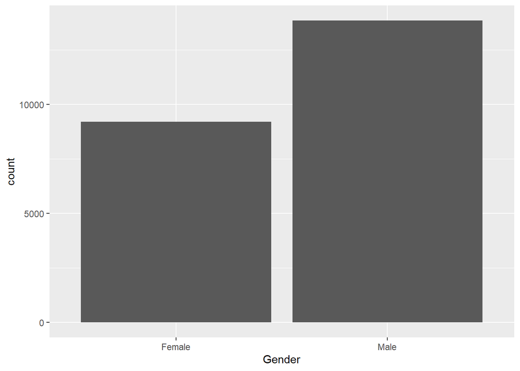

```r
ggplot(dados_rh) + geom_bar(aes(x = Gender))
```

*A maioria das idades tem 30 a 40 anos*

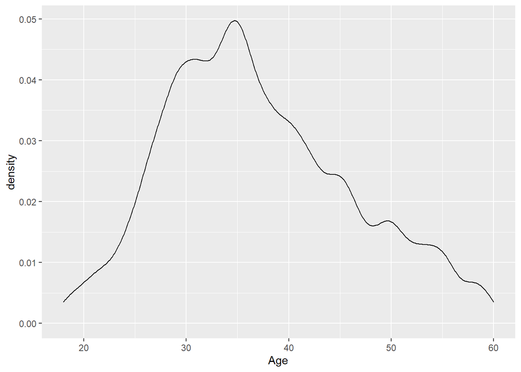

```r
ggplot(dados_rh) + geom_density(aes(x = Age))
```

*A maioria dos colaboradores estão na empresa*

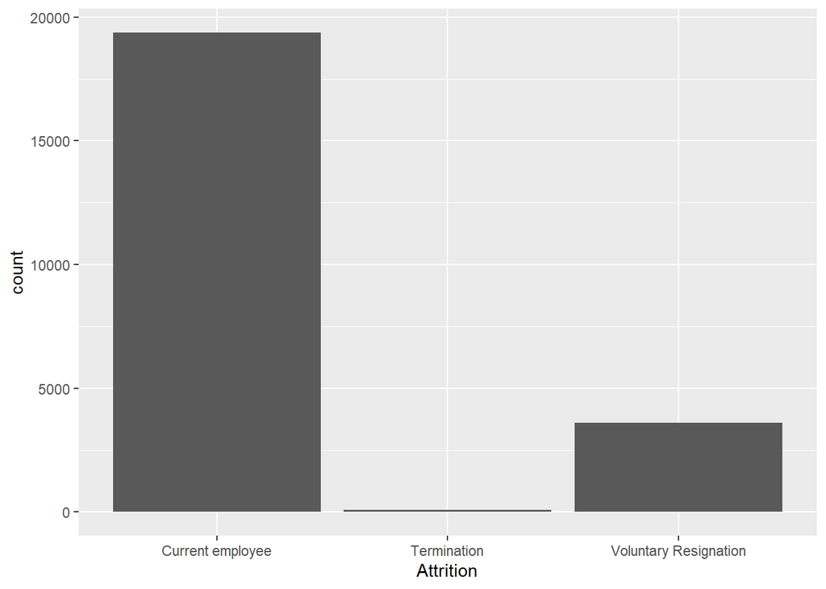

```r
ggplot(dados_rh) + geom_bar(aes(x = Attrition))
```

**A mairia dos colaboradores são da área de pesquisa**

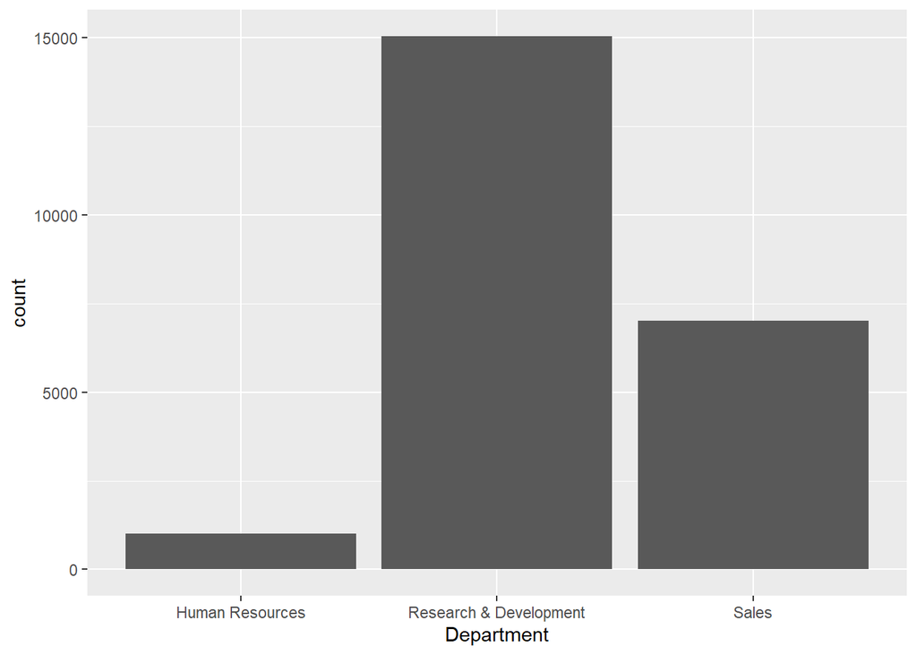

```r
ggplot(dados_rh) + geom_bar(aes(x = Department))
```

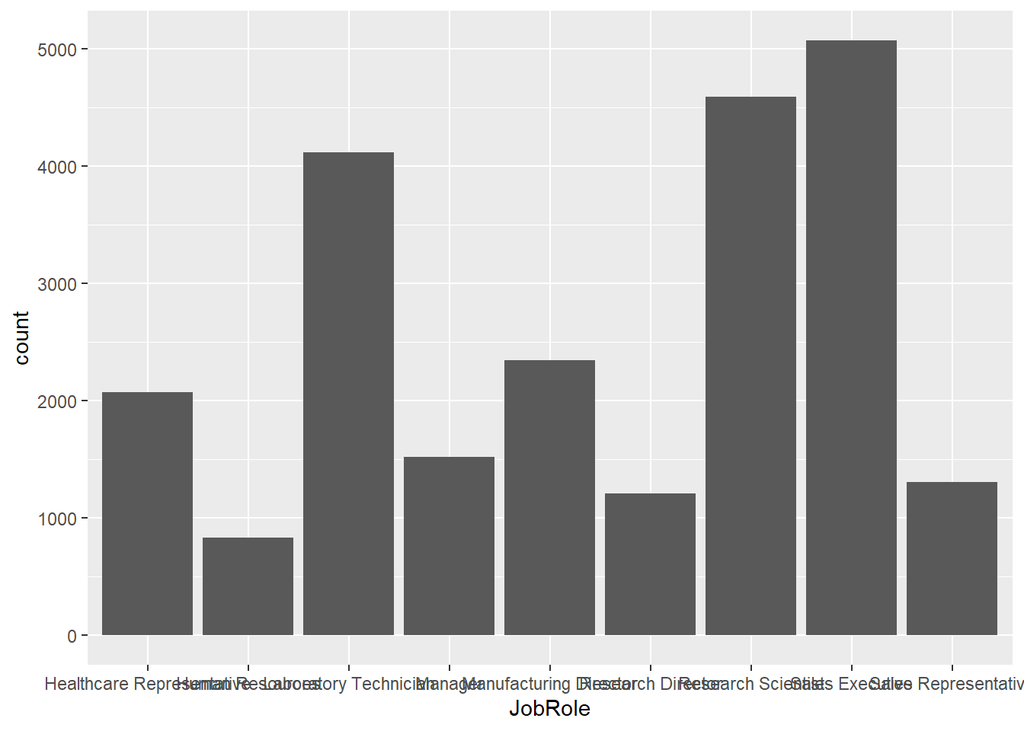

```r
ggplot(dados_rh) + geom_bar(aes(x = JobRole))
```

**A maioria das pessoas tem edução em ciência e da área médica**

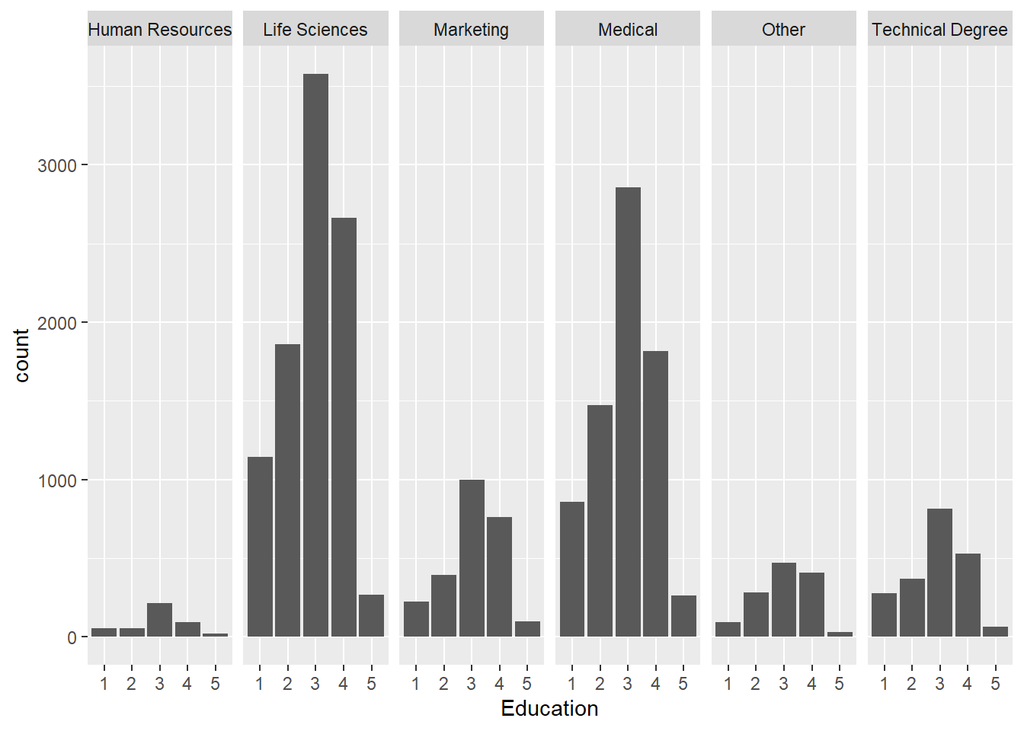

```r
ggplot(dados_rh) + geom_bar(aes(x = Education)) + facet_grid(~EducationField)
```

**Vamos criar Multiplot Grid para comparar variáveis**

```r
p.TotalWorkingYears       <- ggplot(dados_rh) + geom_density(aes(TotalWorkingYears))
p.YearsAtCompany          <- ggplot(dados_rh) + geom_density(aes(YearsAtCompany))
p.YearsSinceLastPromotion <- ggplot(dados_rh) + geom_density(aes(YearsSinceLastPromotion))
p.YearsWithCurrManager    <- ggplot(dados_rh) + geom_density(aes(YearsWithCurrManager))
p.YearsInCurrentRole      <- ggplot(dados_rh) + geom_density(aes(YearsInCurrentRole))
p.PriorYearsOfExperience  <- ggplot(dados_rh) + geom_density(aes(PriorYearsOfExperience))
```

**Organiza no grid**

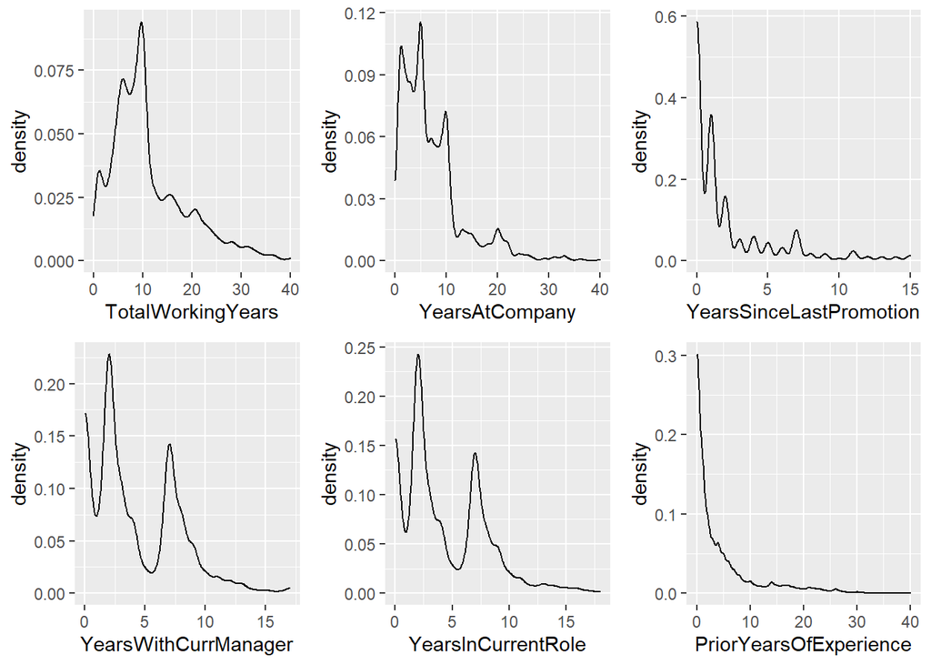

```r
grid.arrange(p.TotalWorkingYears,
             p.YearsAtCompany,
             p.YearsSinceLastPromotion,
             p.YearsWithCurrManager,
             p.YearsInCurrentRole,
             p.PriorYearsOfExperience,
             nrow = 2,
             ncol = 3)
```

**Tempo de experiência anterior. Vamos descobrir a proporção de funcionários com menos de alguns anos de experiência. (valores escolhidos: 1, 3, 5, 7, 10 anos).**

**Podemos ver que 58% dos funcionários têm menos de 3 anos de experiência de trabalho antes de entrar na IBM. Possíveis problemas: conjuntos de habilidades subdesenvolvidos, base de jovens funcionários. mentalidade de “trabalho” imatura.**

```r
length(which(dados_rh$PriorYearsOfExperience < 1)) / length(dados_rh$PriorYearsOfExperience) * 100
```

```
## [1] 32.46596
```

```r
length(which(dados_rh$PriorYearsOfExperience < 3)) / length(dados_rh$PriorYearsOfExperience) * 100
```

```
## [1] 58.28346
```

```r
length(which(dados_rh$PriorYearsOfExperience < 5)) / length(dados_rh$PriorYearsOfExperience)* 100
```

```
## [1] 70.85177
```

```r
length(which(dados_rh$PriorYearsOfExperience < 7)) / length(dados_rh$PriorYearsOfExperience) * 100
```

```
## [1] 79.52121
```

```r
length(which(dados_rh$PriorYearsOfExperience < 10)) / length(dados_rh$PriorYearsOfExperience) * 100
```

```
## [1] 85.89644
```

**Vemos que apenas 22% dos funcionários têm menos de 30 anos, a base de funcionários não é exatamente tão jovem como o esperado.**

**Podemos ver que as pessoas não são tão jovens e com menos experiência.**

```r
length(which(dados_rh$Age < 30)) / length(dados_rh$Age)
```

```
## [1] 0.2165409
```

**Verificar nível da educação**

**Cerca de 39% dos funcionários são graduados e 27% realizaram o mestrado. A busca pelo ensino superior pode ter levado a uma diminuição da experiência de trabalho.**

```r
summary(dados_rh$Education)
```

```
##    1    2    3    4    5
## 2659 4436 8930 6279  754
```

```r
length(which(dados_rh$Education == 3)) / length(dados_rh$Education)
```

```
## [1] 0.3872842
```

```r
length(which(dados_rh$Education == 4)) / length(dados_rh$Education)
```

```
## [1] 0.2723133
```

**Boxplot mostrando a distribuição do salário mensal para todos os 4 níveis de satisfação no trabalho de 1-4**

**Não há sinais óbvios de que um salário mais alto leva a uma maior satisfação no trabalho**

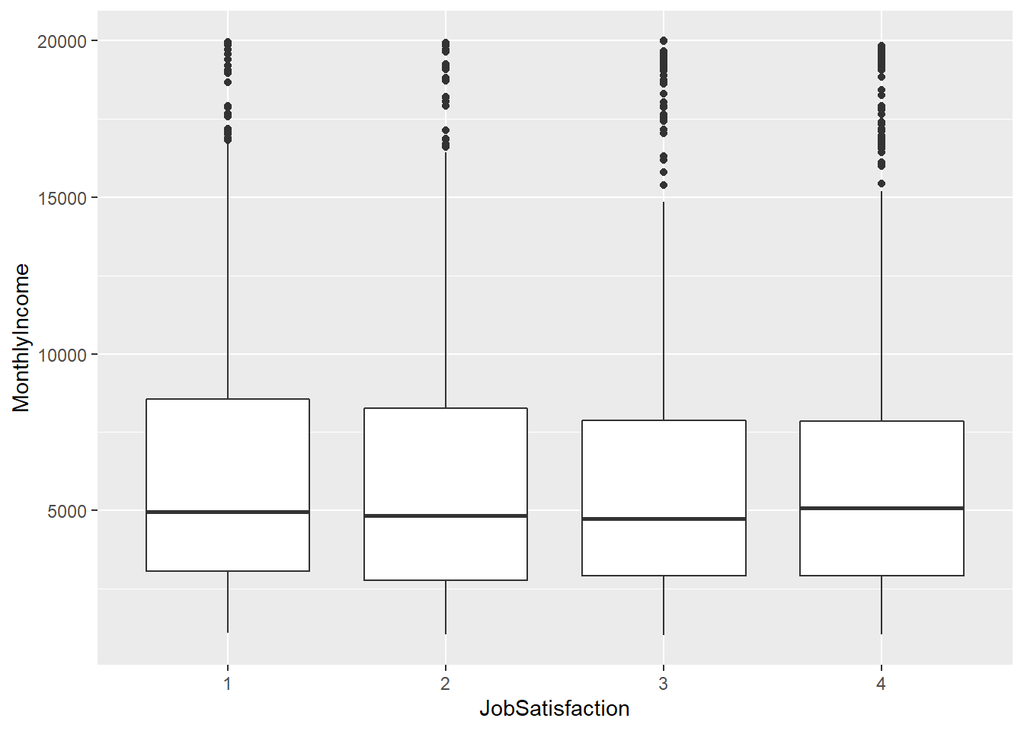

```r
ggplot(data = subset(dados_rh, !is.na(JobSatisfaction)), aes(JobSatisfaction, MonthlyIncome)) +
  geom_boxplot()
```

**Vamos realizar a correlação entre variavéis**

```r
cor(dados_rh$TotalWorkingYears, dados_rh$YearsAtCompany,          use = "complete.obs")
```

```
## [1] 0.624816
```

```r
cor(dados_rh$YearsAtCompany,    dados_rh$YearsInCurrentRole,      use = "complete.obs")
```

```
## [1] 0.7670497
```

```r
cor(dados_rh$YearsAtCompany,    dados_rh$YearsSinceLastPromotion, use = "complete.obs")
```

```
## [1] 0.6236737
```

```r
cor(dados_rh$YearsAtCompany,    dados_rh$YearsWithCurrManager,    use = "complete.obs")
```

```
## [1] 0.7728072
```

```r
cor(dados_rh$TotalWorkingYears, dados_rh$MonthlyIncome,           use = "complete.obs")
```

```
## [1] 0.7582066
```

```r
cor(dados_rh$YearsAtCompany,    dados_rh$MonthlyIncome,           use = "complete.obs")
```

```
## [1] 0.4981578
```

**Scatterplots**

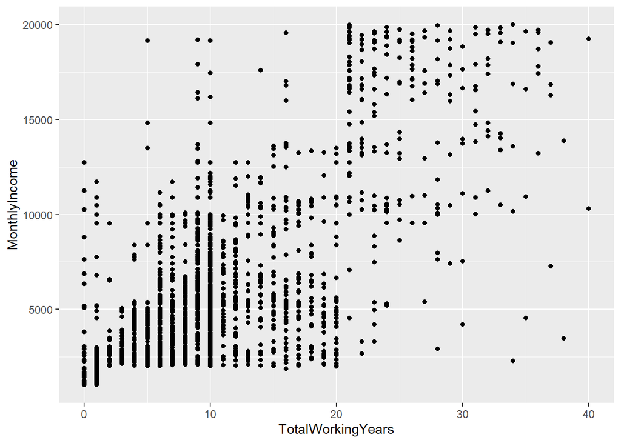

```r
ggplot(dados_rh) + geom_point(aes(TotalWorkingYears, MonthlyIncome))
```

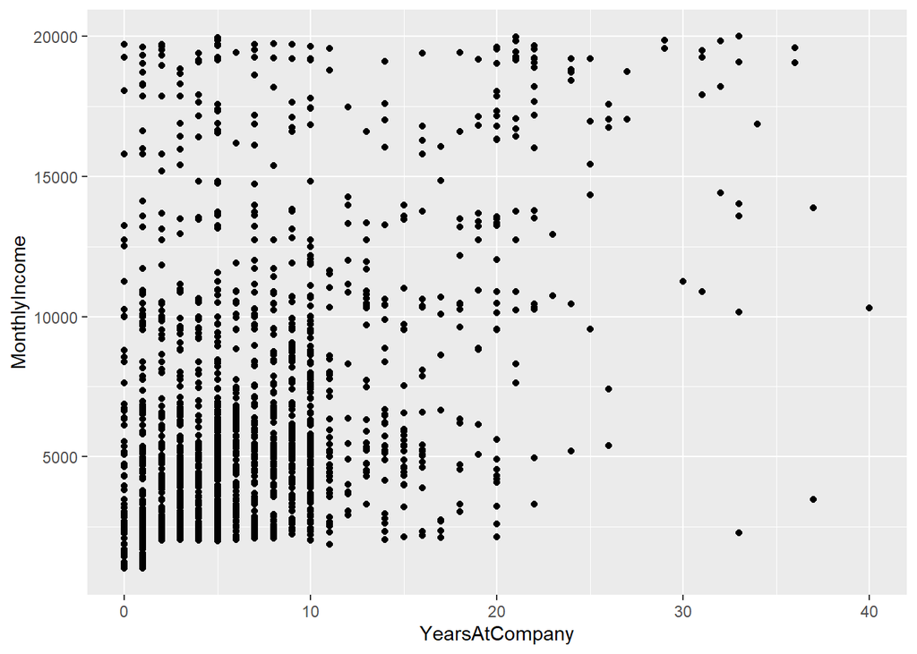

```r
ggplot(dados_rh) + geom_point(aes(YearsAtCompany, MonthlyIncome))
```

**Vamos investigar a relação do equilíbrio entre vida pessoal e profissional e renda mensal**

**Os funcionários que avaliaram o equilíbrio entre vida profissional e pessoal igual a 1 também têm renda média mensal significativamente mais baixa. Baixo equilíbrio entre vida profissional e baixo salário? Um problema que o departamento de RH precisa examinar.**

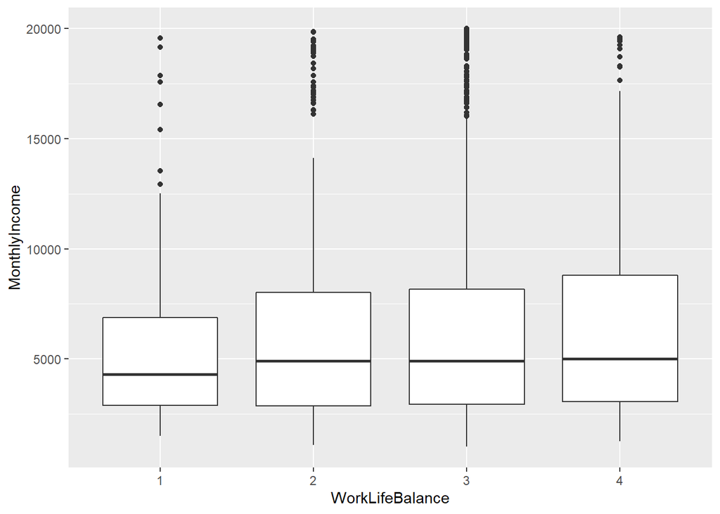

```r
ggplot(data = subset(dados_rh, !is.na(WorkLifeBalance)), aes(WorkLifeBalance, MonthlyIncome)) +
  geom_boxplot()
```

**Verificando a diferença salarial entre homens e mulheres.**

**Não há sinais de discriminação de gênero; na verdade, as mulheres ganham um pouco mais, em média, desconsiderando todos os outros fatores.**

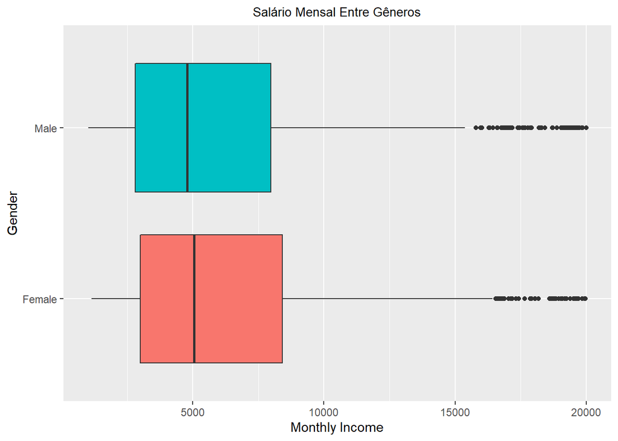

```r
ggplot(data = subset(dados_rh, !is.na(Gender)), aes(Gender, MonthlyIncome, fill = Gender)) +
  geom_boxplot() +
  theme(legend.position = "none", plot.title = element_text(hjust = 0.5, size = 10)) +
  labs(x = "Gender", y = "Monthly Income", title = "Salário Mensal Entre Gêneros") +
  coord_flip()
```

**Vamos criar gráficos de acordo com a Função**

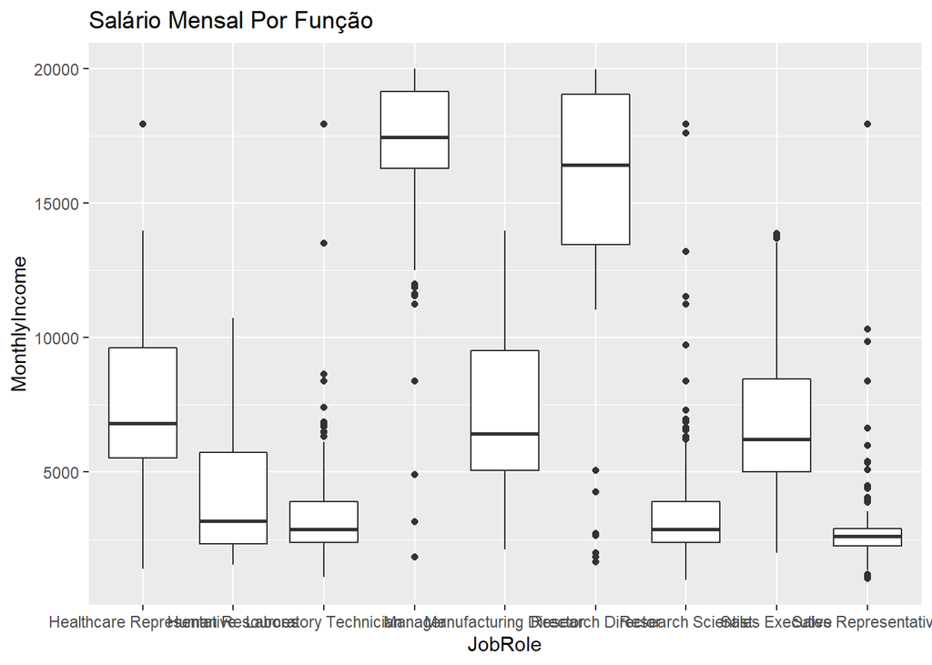

```r
ggplot(data = subset(dados_rh, !is.na(JobRole))) + geom_boxplot(aes(JobRole, MonthlyIncome)) +
  ggtitle("Salário Mensal Por Função")
```

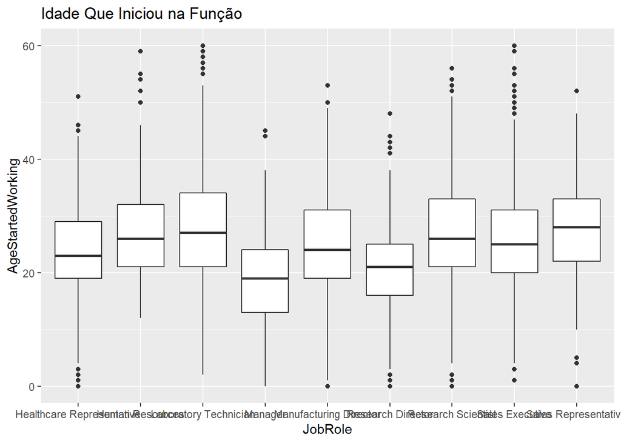

```r
ggplot(data = subset(dados_rh, !is.na(JobRole))) + geom_boxplot(aes(JobRole, AgeStartedWorking)) +
  ggtitle("Idade Que Iniciou na Função")
```

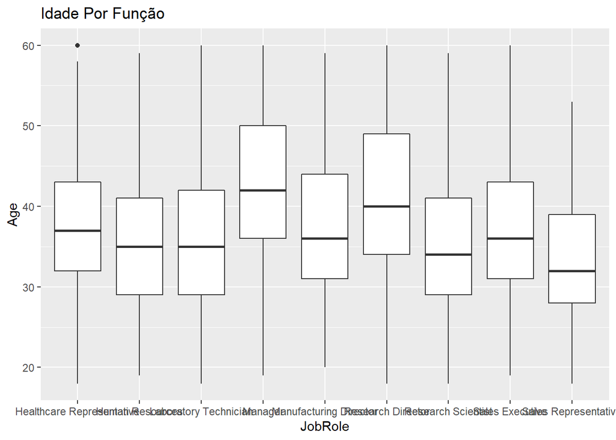

```r
ggplot(data = subset(dados_rh, !is.na(JobRole))) + geom_boxplot(aes(JobRole, Age)) +
  ggtitle("Idade Por Função")
```

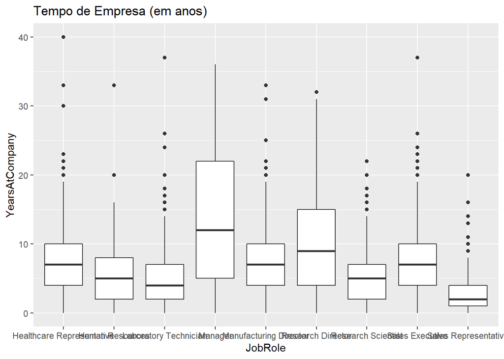

```r
ggplot(data = subset(dados_rh, !is.na(JobRole))) + geom_boxplot(aes(JobRole, YearsAtCompany)) +
  ggtitle("Tempo de Empresa (em anos)")
```

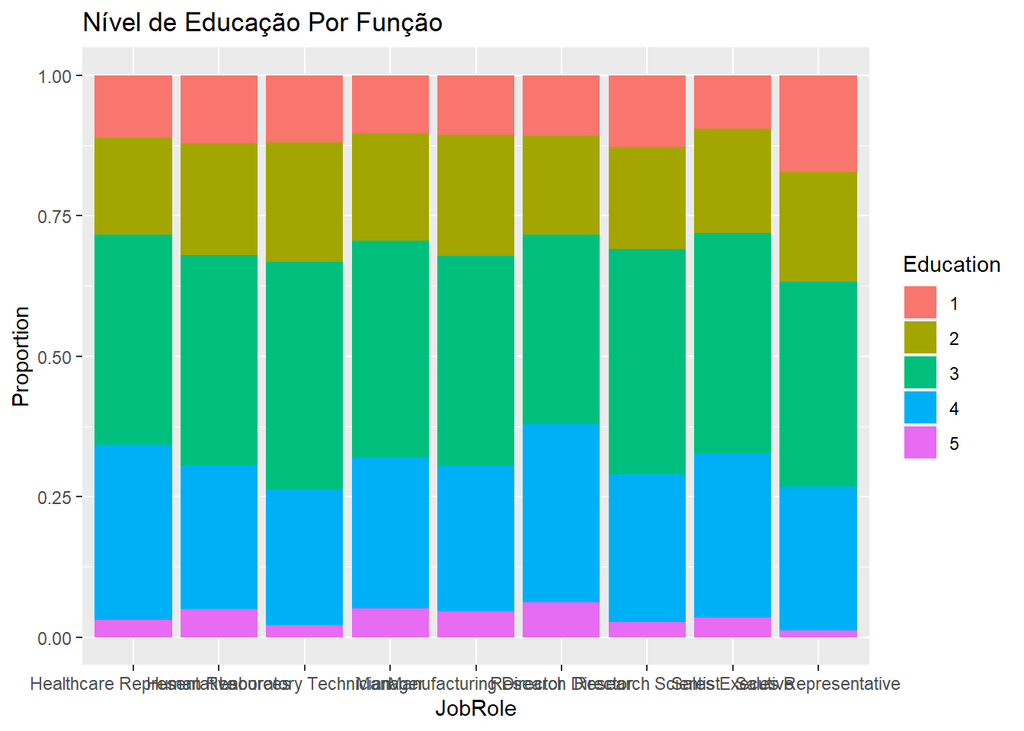

```r
ggplot(data = na.omit(dados_rh)) + geom_bar(aes(JobRole, fill = Education), position = "fill") +
  ggtitle("Nível de Educação Por Função") +
  ylab("Proportion")
```

**Plots de análise multivariada para variáveis normalmente usadas durante o processo de contratação**

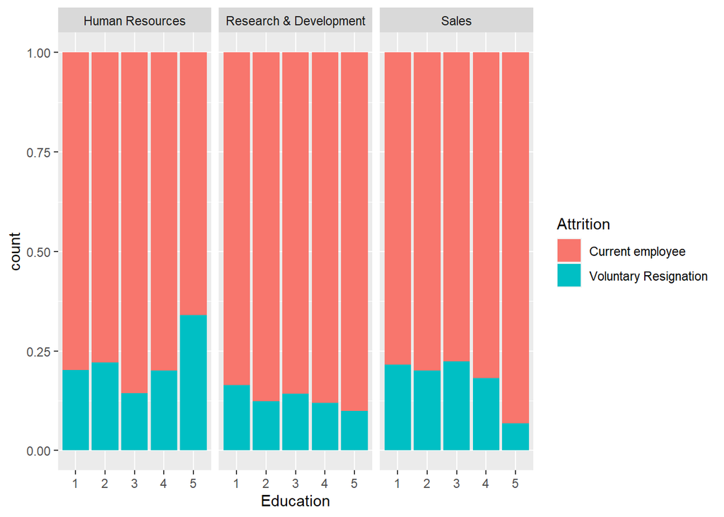

```r
ggplot(data = dados_rh_1) +
  geom_bar(aes(x = Education , fill = Attrition), position = 'fill') +
  facet_grid(.~Department)
```

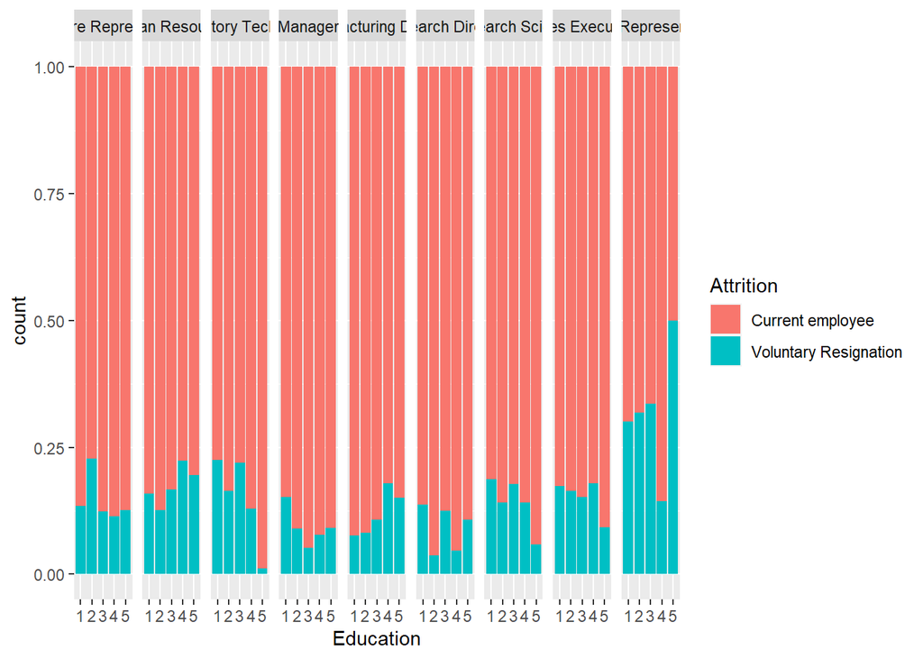

```r
ggplot(data = dados_rh_1) +
  geom_bar(aes(x = Education , fill = Attrition), position = 'fill') +
  facet_grid(.~JobRole)
```

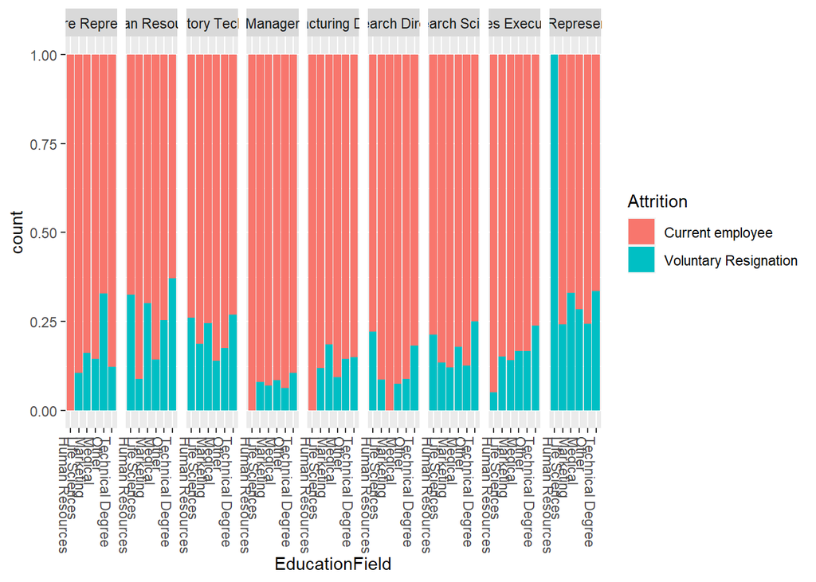

```r
ggplot(data = dados_rh_1) +
  geom_bar(aes(x = EducationField , fill = Attrition), position = 'fill') +
  facet_grid(.~JobRole) +
  theme(axis.text.x = element_text(angle = -90, hjust = 0))
```

**Plots de análise multivariada para variáveis normalmente usadas após o processo de contratação**

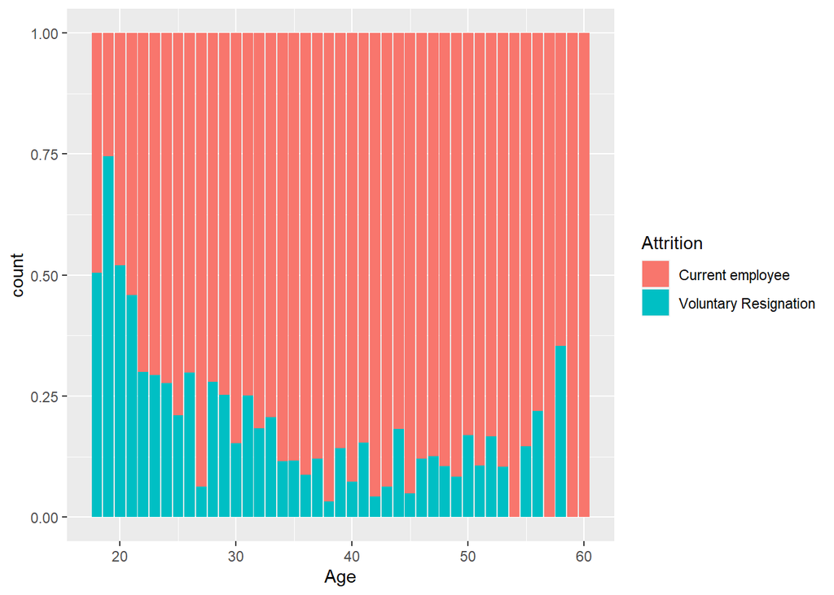

```r
ggplot(dados_rh_1) + geom_bar(aes(x = Age, fill = Attrition), position = 'fill')
```

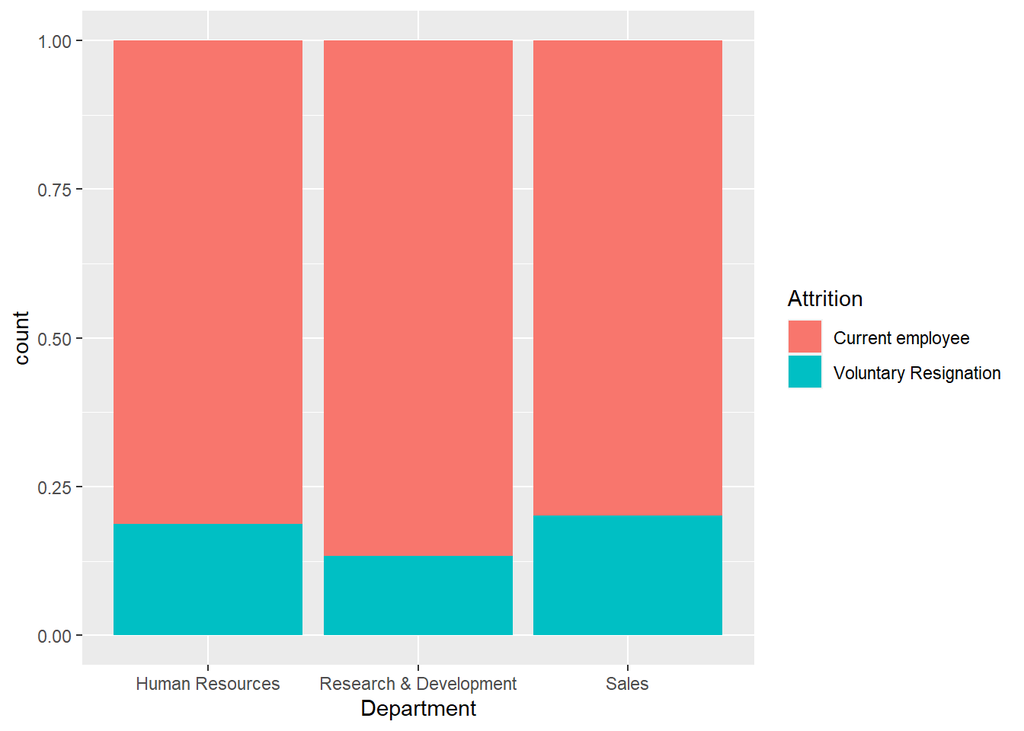

```r
ggplot(dados_rh_1) + geom_bar(aes(x = Department, fill = Attrition), position = 'fill')
```

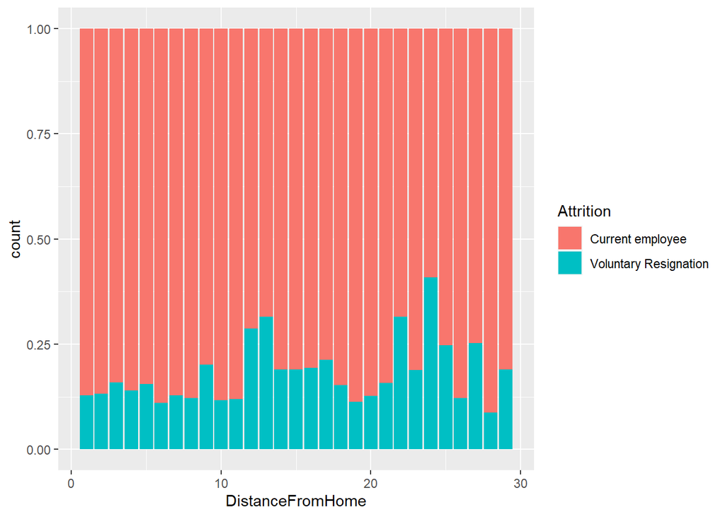

```r
ggplot(dados_rh_1) + geom_bar(aes(x = DistanceFromHome, fill = Attrition), position = 'fill')
```

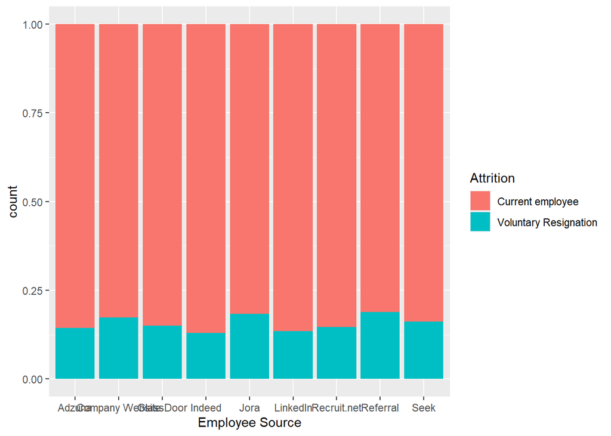

```r
ggplot(dados_rh_1) + geom_bar(aes(x = `Employee Source`, fill = Attrition), position = 'fill')
```

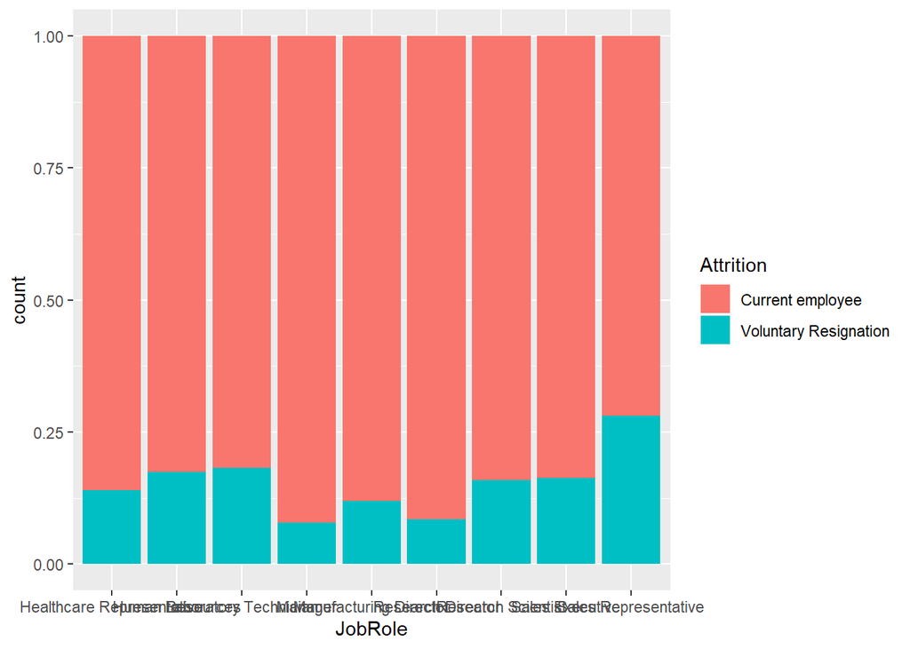

```r
ggplot(dados_rh_1) + geom_bar(aes(x = JobRole, fill = Attrition), position = 'fill')
```

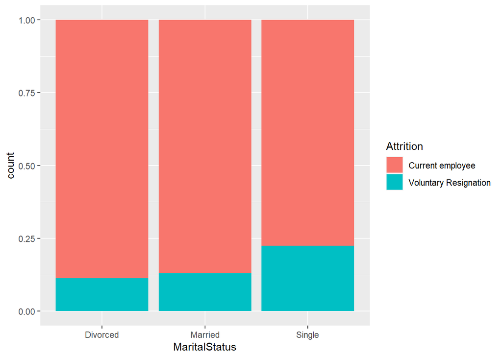

```r
ggplot(dados_rh_1) + geom_bar(aes(x = MaritalStatus, fill = Attrition), position = 'fill')
```

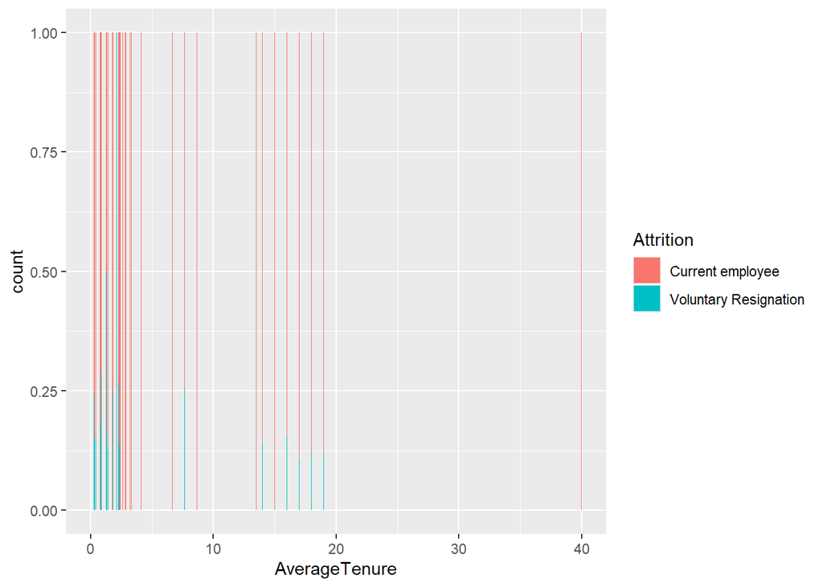

```r
ggplot(dados_rh_1) + geom_bar(aes(x = AverageTenure, fill = Attrition), position = 'fill')
```

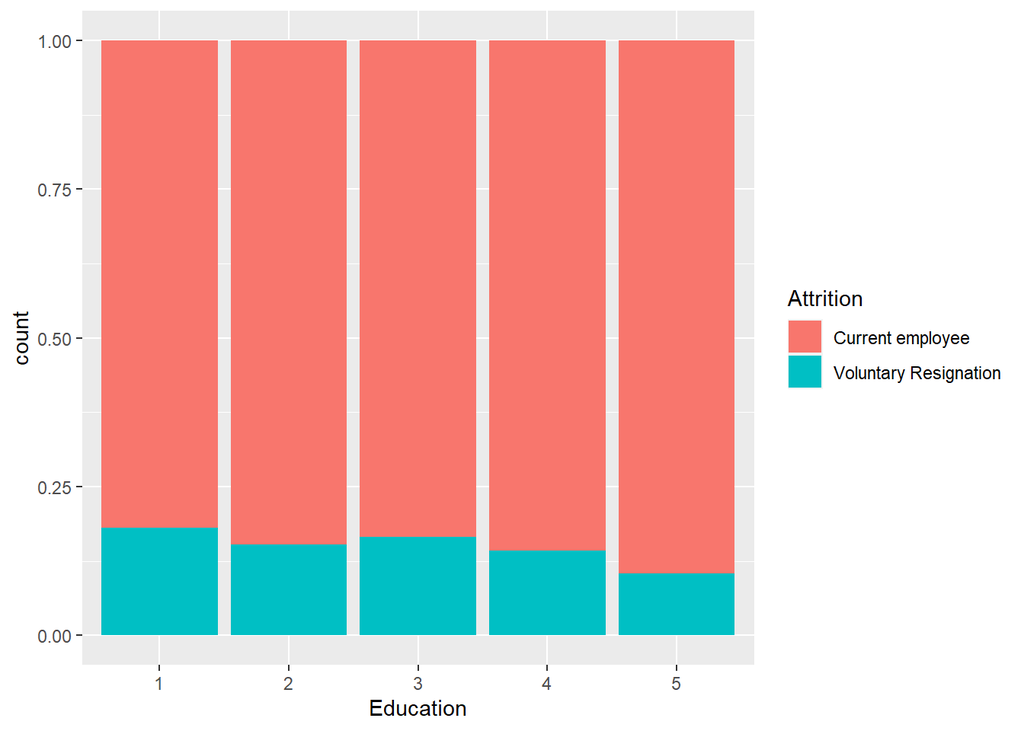

```r
ggplot(dados_rh_1) + geom_bar(aes(x = Education, fill = Attrition), position = 'fill')
```

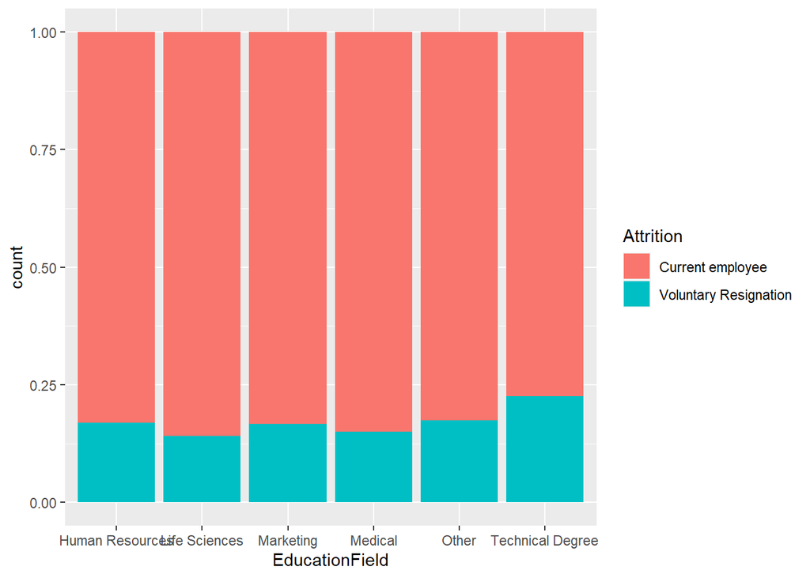

```r
ggplot(dados_rh_1) + geom_bar(aes(x = EducationField, fill = Attrition),position ='fill')
```

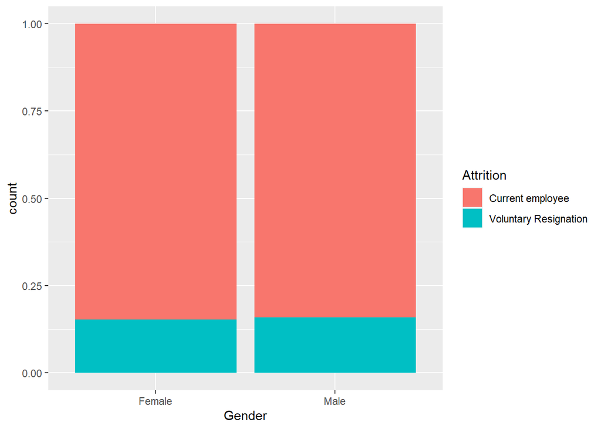

```r
ggplot(dados_rh_1) + geom_bar(aes(x = Gender, fill = Attrition), position = 'fill')
```

**Plots de análise multivariada entre algumas variáveis e o status do funcionário**

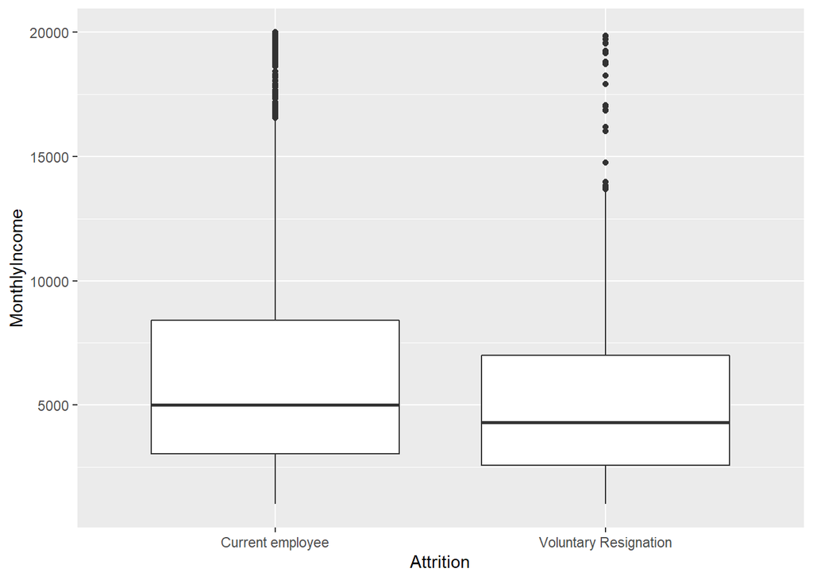

```r
ggplot(dados_rh_1) + geom_boxplot(aes(Attrition, MonthlyIncome))
```

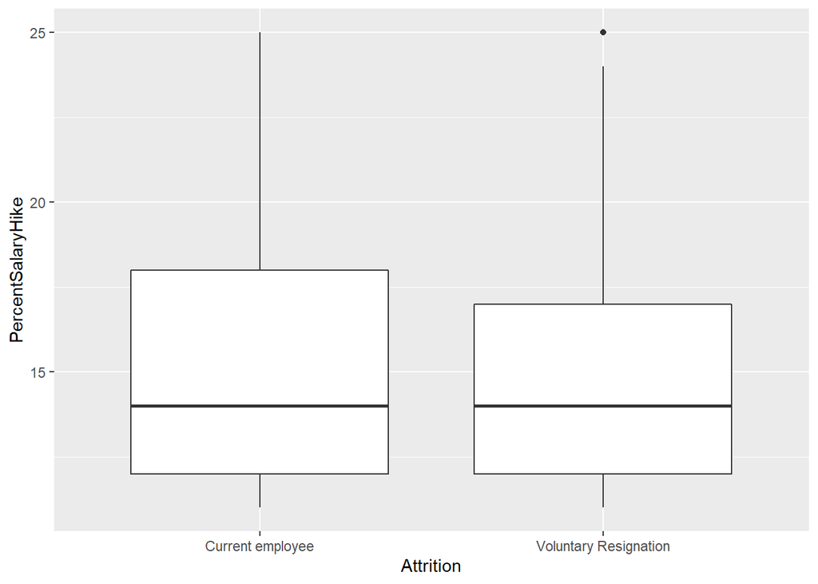

```r
ggplot(dados_rh_1) + geom_boxplot(aes(Attrition, PercentSalaryHike))
```

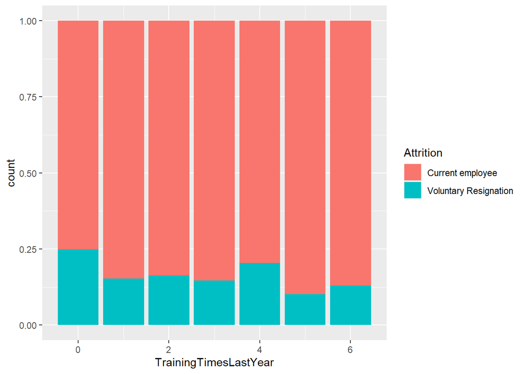

```r
ggplot(dados_rh_1) + geom_bar(aes(TrainingTimesLastYear, fill = Attrition), position = 'fill')
```

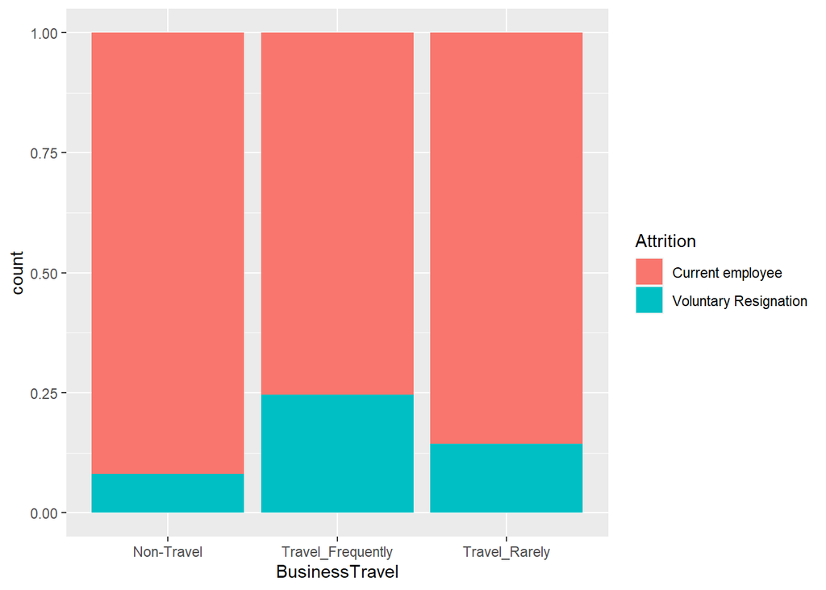

```r
ggplot(dados_rh_1) + geom_bar(aes(BusinessTravel, fill = Attrition), position = 'fill')
```

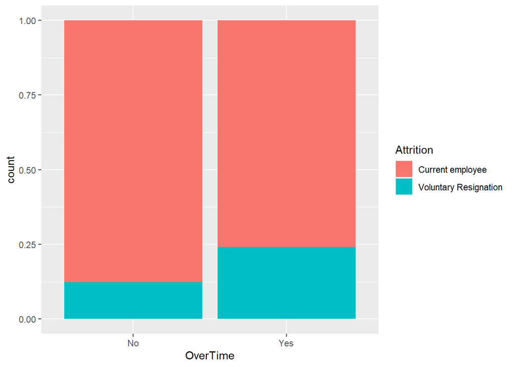

```r
ggplot(dados_rh_1) + geom_bar(aes(OverTime, fill = Attrition), position = 'fill')
```

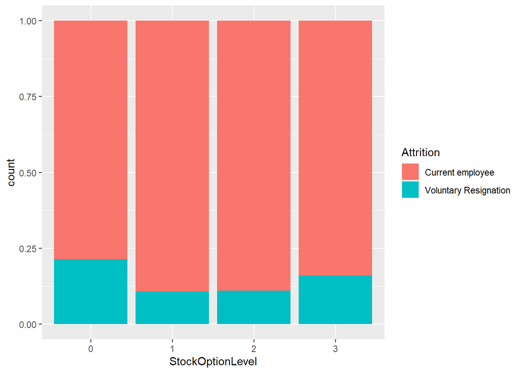

```r
ggplot(dados_rh_1) + geom_bar(aes(StockOptionLevel, fill = Attrition), position = 'fill')
```

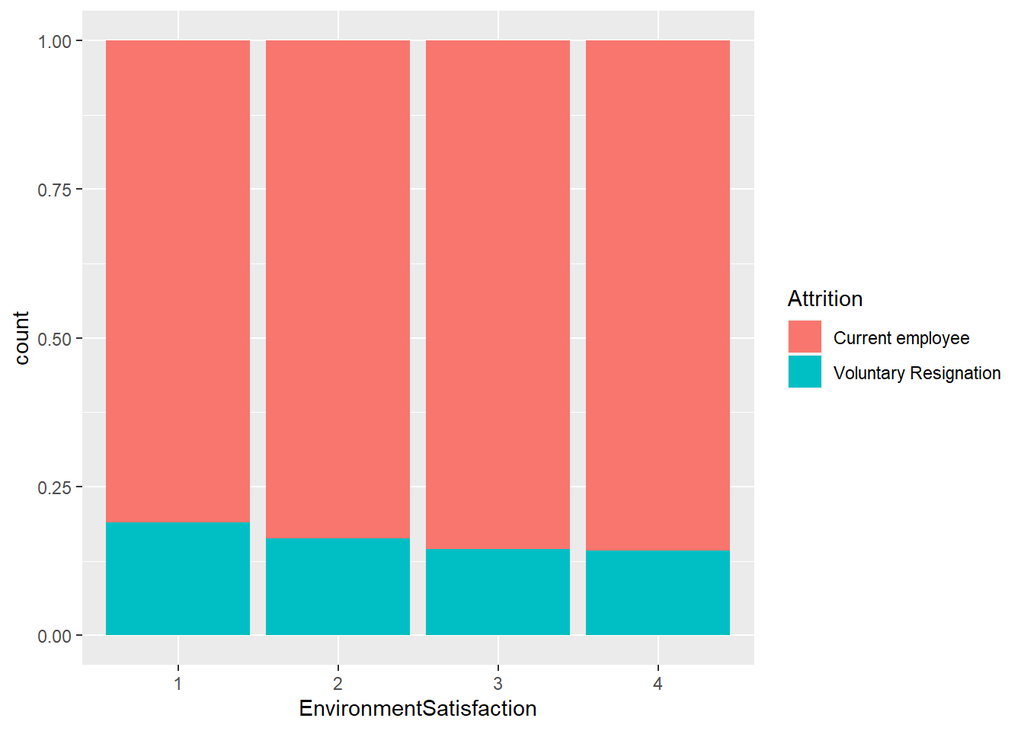

```r
ggplot(dados_rh_1) + geom_bar(aes(EnvironmentSatisfaction, fill = Attrition), position = 'fill')
```

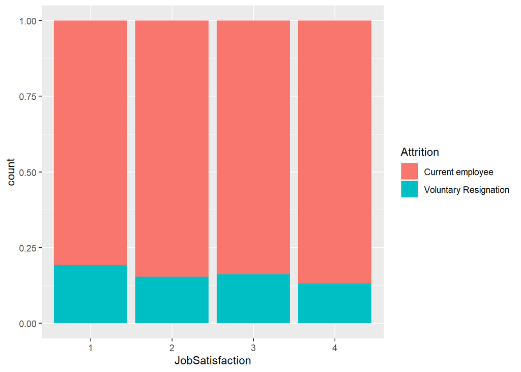

```r
ggplot(dados_rh_1) + geom_bar(aes(JobSatisfaction, fill = Attrition), position = 'fill')
```

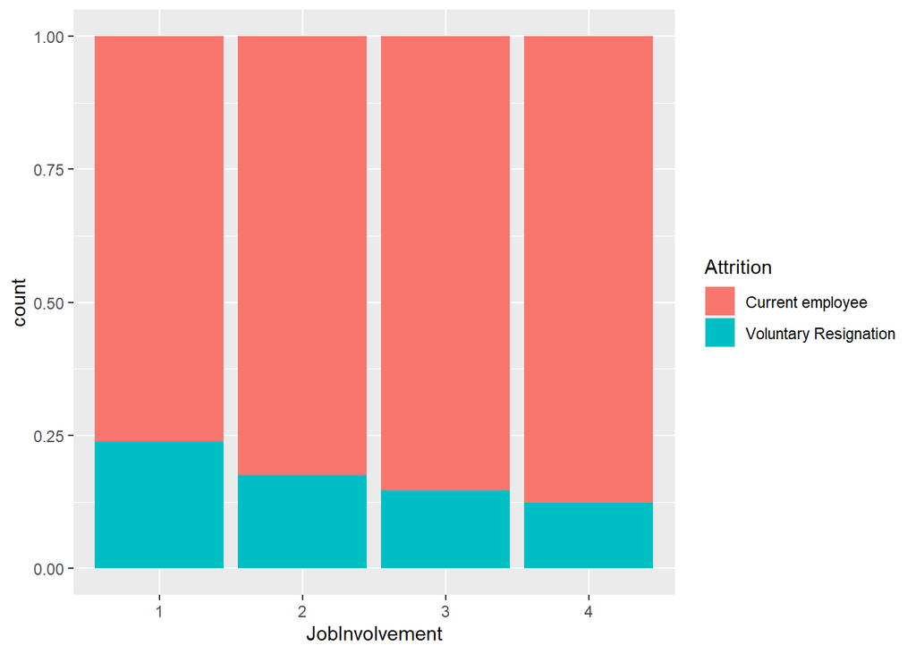

```r
ggplot(dados_rh_1) + geom_bar(aes(JobInvolvement, fill = Attrition), position = 'fill')
```

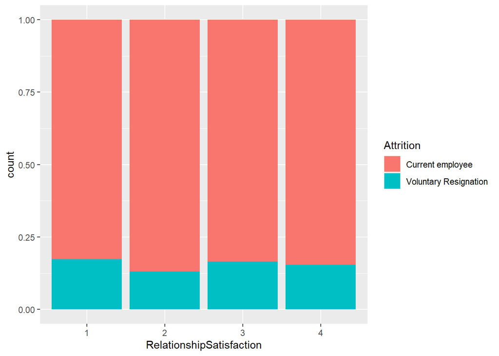

```r
ggplot(dados_rh_1) + geom_bar(aes(RelationshipSatisfaction, fill = Attrition), position = 'fill')
```

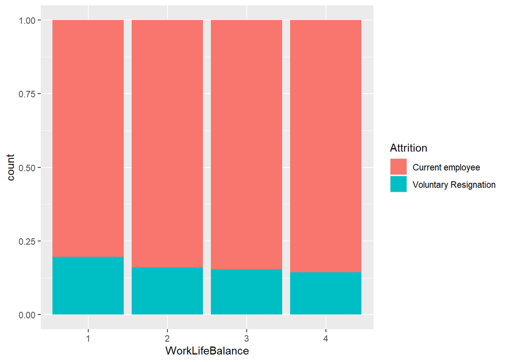

```r
ggplot(dados_rh_1) + geom_bar(aes(WorkLifeBalance, fill = Attrition), position = 'fill')
```

**Modelagem Preditiva**

**Vamos concentrar nosso trabalho em tentar ajudar o RH a recrutar melhor visando evitar atritos e, consequentemente, demissões.**

**Criaremos 5 versões do modelo e para cada um vamos explorar as opções e interpretar o resultado.**

**Primeira versão do modelo com algumas variáveis**

```r
modelo_v1 <- glm(Attrition ~ Age + Department + DistanceFromHome + `Employee Source` +
                   JobRole + MaritalStatus + AverageTenure + PriorYearsOfExperience + Gender +
                   Education + EducationField,
                 family = binomial,
                 data = dados_rh)
```

**Podemos ver que a idade, área de pesquisa tem alta correlação com os atritos**

```r
summary(modelo_v1)
```

```
##
## Call:
## glm(formula = Attrition ~ Age + Department + DistanceFromHome +
##     `Employee Source` + JobRole + MaritalStatus + AverageTenure +
##     PriorYearsOfExperience + Gender + Education + EducationField,
##     family = binomial, data = dados_rh)
##
## Deviance Residuals:
##     Min       1Q   Median       3Q      Max
## -1.4738  -0.6239  -0.4962  -0.3553   2.7405
##
## Coefficients:
##                                   Estimate Std. Error z value Pr(>|z|)
## (Intercept)                      -0.515415   0.198808  -2.593 0.009527 **
## Age                              -0.046402   0.002434 -19.062  < 2e-16 ***
## DepartmentResearch & Development -0.402413   0.102837  -3.913 9.11e-05 ***
## DepartmentSales                   0.041108   0.106275   0.387 0.698901
## DistanceFromHome                  0.022014   0.002497   8.816  < 2e-16 ***
## `Employee Source`Company Website  0.200175   0.074567   2.684 0.007264 **
## `Employee Source`GlassDoor       -0.002062   0.089568  -0.023 0.981630
## `Employee Source`Indeed          -0.048126   0.088966  -0.541 0.588545
## `Employee Source`Jora             0.202494   0.084534   2.395 0.016602 *
## `Employee Source`LinkedIn        -0.086527   0.090292  -0.958 0.337911
## `Employee Source`Recruit.net     -0.024145   0.088800  -0.272 0.785699
## `Employee Source`Referral         0.222132   0.147177   1.509 0.131226
## `Employee Source`Seek             0.039192   0.079096   0.495 0.620253
## JobRoleHuman Resources            0.092163   0.125250   0.736 0.461832
## JobRoleLaboratory Technician      0.313456   0.079749   3.931 8.48e-05 ***
## JobRoleManager                   -0.370055   0.121400  -3.048 0.002302 **
## JobRoleManufacturing Director    -0.091942   0.094178  -0.976 0.328937
## JobRoleResearch Director         -0.326907   0.125855  -2.597 0.009391 **
## JobRoleResearch Scientist         0.102218   0.078537   1.302 0.193080
## JobRoleSales Executive           -0.030434   0.079097  -0.385 0.700414
## JobRoleSales Representative       0.484732   0.095181   5.093 3.53e-07 ***
## MaritalStatusMarried              0.179376   0.053279   3.367 0.000761 ***
## MaritalStatusSingle               0.740422   0.053393  13.867  < 2e-16 ***
## AverageTenure                    -0.016927   0.009230  -1.834 0.066663 .
## PriorYearsOfExperience            0.018901   0.005353   3.531 0.000414 ***
## GenderMale                        0.033768   0.038421   0.879 0.379467
## Education2                        0.096221   0.068965   1.395 0.162951
## Education3                        0.129656   0.061109   2.122 0.033862 *
## Education4                        0.120603   0.066456   1.815 0.069558 .
## Education5                       -0.221560   0.134302  -1.650 0.099001 .
## EducationFieldLife Sciences      -0.149802   0.143779  -1.042 0.297462
## EducationFieldMarketing          -0.122315   0.152984  -0.800 0.423984
## EducationFieldMedical            -0.176829   0.145066  -1.219 0.222859
## EducationFieldOther              -0.170949   0.161651  -1.058 0.290274
## EducationFieldTechnical Degree    0.183255   0.154276   1.188 0.234898
## ---
## Signif. codes:  0 '***' 0.001 '**' 0.01 '*' 0.05 '.' 0.1 ' ' 1
##
## (Dispersion parameter for binomial family taken to be 1)
##
##     Null deviance: 20272  on 23057  degrees of freedom
## Residual deviance: 18904  on 23023  degrees of freedom
## AIC: 18974
##
## Number of Fisher Scoring iterations: 5
```

**Departamento, função, tempo de emprego e total de anos de experiência tem alta relevancia para levar em consideração para gerar atrito**

```r
vif(modelo_v1)
```

```
##                            GVIF Df GVIF^(1/(2*Df))
## Age                    1.197853  1        1.094465
## Department             2.027501  2        1.193274
## DistanceFromHome       1.321206  1        1.149437
## `Employee Source`      1.107922  8        1.006426
## JobRole                2.564522  8        1.060628
## MaritalStatus          1.042578  2        1.010479
## AverageTenure          2.478002  1        1.574167
## PriorYearsOfExperience 2.440072  1        1.562073
## Gender                 1.019571  1        1.009738
## Education              1.121235  4        1.014407
## EducationField         1.648089  5        1.051231
```

**Vamos dividir os dados em treino e teste. Vamos trabalhar com os dados sem registros de demitidos.**

```r
set.seed(2004)
index_treino <- sample.split(Y = dados_rh_1$Attrition, SplitRatio = 0.7)
dados_rh_1_treino <- subset(dados_rh_1, train = T)
dados_rh_1_teste <- subset(dados_rh_1, train = F)
```

**Segunda versão do modelo com dados de treino**

```r
modelo_v2 <- glm(Attrition ~ Age + Department + DistanceFromHome + `Employee Source` +
                   JobRole + MaritalStatus + AverageTenure + PriorYearsOfExperience + Gender +
                   Education + EducationField,
                 family = binomial,
                 data = dados_rh_1_treino)
```

```r
summary(modelo_v2)
```

```
##
## Call:
## glm(formula = Attrition ~ Age + Department + DistanceFromHome +
##     `Employee Source` + JobRole + MaritalStatus + AverageTenure +
##     PriorYearsOfExperience + Gender + Education + EducationField,
##     family = binomial, data = dados_rh_1_treino)
##
## Deviance Residuals:
##     Min       1Q   Median       3Q      Max
## -1.4484  -0.6177  -0.4918  -0.3558   2.7300
##
## Coefficients:
##                                   Estimate Std. Error z value Pr(>|z|)
## (Intercept)                      -0.499751   0.199492  -2.505 0.012241 *
## Age                              -0.044889   0.002446 -18.348  < 2e-16 ***
## DepartmentResearch & Development -0.427955   0.103053  -4.153 3.28e-05 ***
## DepartmentSales                   0.025684   0.106499   0.241 0.809423
## DistanceFromHome                  0.020372   0.002522   8.076 6.69e-16 ***
## `Employee Source`Company Website  0.183335   0.074868   2.449 0.014334 *
## `Employee Source`GlassDoor        0.006274   0.089680   0.070 0.944229
## `Employee Source`Indeed          -0.080908   0.089734  -0.902 0.367244
## `Employee Source`Jora             0.183678   0.084958   2.162 0.030618 *
## `Employee Source`LinkedIn        -0.079145   0.090405  -0.875 0.381325
## `Employee Source`Recruit.net     -0.050665   0.089444  -0.566 0.571095
## `Employee Source`Referral         0.230121   0.147168   1.564 0.117897
## `Employee Source`Seek            -0.005837   0.079828  -0.073 0.941708
## JobRoleHuman Resources            0.107348   0.125753   0.854 0.393302
## JobRoleLaboratory Technician      0.314968   0.080707   3.903 9.52e-05 ***
## JobRoleManager                   -0.402633   0.123788  -3.253 0.001144 **
## JobRoleManufacturing Director    -0.083426   0.095273  -0.876 0.381221
## JobRoleResearch Director         -0.292195   0.126243  -2.315 0.020637 *
## JobRoleResearch Scientist         0.111877   0.079359   1.410 0.158608
## JobRoleSales Executive           -0.028140   0.079873  -0.352 0.724611
## JobRoleSales Representative       0.478077   0.096067   4.977 6.47e-07 ***
## MaritalStatusMarried              0.176289   0.053865   3.273 0.001065 **
## MaritalStatusSingle               0.747383   0.053896  13.867  < 2e-16 ***
## AverageTenure                    -0.021245   0.009467  -2.244 0.024825 *
## PriorYearsOfExperience            0.019787   0.005399   3.665 0.000248 ***
## GenderMale                        0.030982   0.038752   0.800 0.424000
## Education2                        0.067584   0.069195   0.977 0.328712
## Education3                        0.092553   0.061236   1.511 0.130684
## Education4                        0.071013   0.066760   1.064 0.287461
## Education5                       -0.233758   0.134267  -1.741 0.081685 .
## EducationFieldLife Sciences      -0.148858   0.143810  -1.035 0.300620
## EducationFieldMarketing          -0.106268   0.152995  -0.695 0.487317
## EducationFieldMedical            -0.202212   0.145203  -1.393 0.163736
## EducationFieldOther              -0.137807   0.161652  -0.852 0.393940
## EducationFieldTechnical Degree    0.180977   0.154552   1.171 0.241608
## ---
## Signif. codes:  0 '***' 0.001 '**' 0.01 '*' 0.05 '.' 0.1 ' ' 1
##
## (Dispersion parameter for binomial family taken to be 1)
##
##     Null deviance: 19951  on 22970  degrees of freedom
## Residual deviance: 18626  on 22936  degrees of freedom
## AIC: 18696
##
## Number of Fisher Scoring iterations: 5
```

```r
vif(modelo_v2)
```

```
##                            GVIF Df GVIF^(1/(2*Df))
## Age                    1.196689  1        1.093933
## Department             2.033631  2        1.194175
## DistanceFromHome       1.321839  1        1.149712
## `Employee Source`      1.109202  8        1.006499
## JobRole                2.550173  8        1.060256
## MaritalStatus          1.043120  2        1.010610
## AverageTenure          2.441327  1        1.562475
## PriorYearsOfExperience 2.412397  1        1.553189
## Gender                 1.018652  1        1.009283
## Education              1.123257  4        1.014635
## EducationField         1.650765  5        1.051401
```

**Previsões**

```r
threshold <- 0.5
previsoes_v2 <- predict(modelo_v2, type = 'response', newdata = dados_rh_1_teste)
previsoes_finais_v2 <- ifelse(previsoes_v2 > threshold, 'Voluntary Resignation', 'Current employee')
table(dados_rh_1_teste$Attrition, previsoes_finais_v2)
```

```
##                        previsoes_finais_v2
##                         Current employee Voluntary Resignation
##   Current employee                 19328                    42
##   Voluntary Resignation             3523                    78
```

**Terceira versão do modelo com dados de treino e sem variáveis de educação**

```r
modelo_v3 <- glm(Attrition ~ Age + Department + DistanceFromHome + `Employee Source` +
                   JobRole + MaritalStatus + AverageTenure + PriorYearsOfExperience + Gender,
                 family = binomial,
                 data = dados_rh_1_treino)
```

```r
summary(modelo_v3)
```

```
##
## Call:
## glm(formula = Attrition ~ Age + Department + DistanceFromHome +
##     `Employee Source` + JobRole + MaritalStatus + AverageTenure +
##     PriorYearsOfExperience + Gender, family = binomial, data = dados_rh_1_treino)
##
## Deviance Residuals:
##     Min       1Q   Median       3Q      Max
## -1.3428  -0.6201  -0.4941  -0.3619   2.7143
##
## Coefficients:
##                                   Estimate Std. Error z value Pr(>|z|)
## (Intercept)                      -0.594443   0.163302  -3.640 0.000272 ***
## Age                              -0.044338   0.002361 -18.781  < 2e-16 ***
## DepartmentResearch & Development -0.455831   0.097648  -4.668 3.04e-06 ***
## DepartmentSales                   0.006375   0.100798   0.063 0.949567
## DistanceFromHome                  0.023945   0.002219  10.792  < 2e-16 ***
## `Employee Source`Company Website  0.185836   0.074684   2.488 0.012835 *
## `Employee Source`GlassDoor        0.004131   0.089469   0.046 0.963174
## `Employee Source`Indeed          -0.084488   0.089587  -0.943 0.345638
## `Employee Source`Jora             0.182141   0.084629   2.152 0.031378 *
## `Employee Source`LinkedIn        -0.073833   0.090249  -0.818 0.413300
## `Employee Source`Recruit.net     -0.058670   0.089241  -0.657 0.510903
## `Employee Source`Referral         0.237922   0.146800   1.621 0.105078
## `Employee Source`Seek            -0.006818   0.079571  -0.086 0.931717
## JobRoleHuman Resources            0.099083   0.125594   0.789 0.430163
## JobRoleLaboratory Technician      0.312339   0.080556   3.877 0.000106 ***
## JobRoleManager                   -0.418085   0.123665  -3.381 0.000723 ***
## JobRoleManufacturing Director    -0.079696   0.095061  -0.838 0.401826
## JobRoleResearch Director         -0.308958   0.126075  -2.451 0.014263 *
## JobRoleResearch Scientist         0.119993   0.079265   1.514 0.130071
## JobRoleSales Executive           -0.023432   0.079774  -0.294 0.768961
## JobRoleSales Representative       0.483836   0.095952   5.042 4.60e-07 ***
## MaritalStatusMarried              0.176480   0.053793   3.281 0.001035 **
## MaritalStatusSingle               0.747665   0.053772  13.904  < 2e-16 ***
## AverageTenure                    -0.019906   0.009465  -2.103 0.035453 *
## PriorYearsOfExperience            0.019187   0.005400   3.553 0.000381 ***
## GenderMale                        0.033764   0.038690   0.873 0.382838
## ---
## Signif. codes:  0 '***' 0.001 '**' 0.01 '*' 0.05 '.' 0.1 ' ' 1
##
## (Dispersion parameter for binomial family taken to be 1)
##
##     Null deviance: 19951  on 22970  degrees of freedom
## Residual deviance: 18668  on 22945  degrees of freedom
## AIC: 18720
##
## Number of Fisher Scoring iterations: 5
```

```r
vif(modelo_v3)
```

```
##                            GVIF Df GVIF^(1/(2*Df))
## Age                    1.116616  1        1.056701
## Department             1.733091  2        1.147375
## DistanceFromHome       1.008189  1        1.004086
## `Employee Source`      1.080863  8        1.004872
## JobRole                2.519868  8        1.059464
## MaritalStatus          1.037566  2        1.009262
## AverageTenure          2.443412  1        1.563142
## PriorYearsOfExperience 2.418527  1        1.555161
## Gender                 1.017671  1        1.008797
```

**Previsões**

```r
threshold <- 0.5
previsoes_v3 <- predict(modelo_v3, type = 'response', newdata = dados_rh_1_teste)
previsoes_finais_v3 <- ifelse(previsoes_v3 > threshold, 'Voluntary Resignation', 'Current employee')
table(dados_rh_1_teste$Attrition, previsoes_finais_v3)
```

```
##                        previsoes_finais_v3
##                         Current employee Voluntary Resignation
##   Current employee                 19328                    42
##   Voluntary Resignation             3541                    60
```

**Quarta versão do modelo com dados de treino e sem variáveis de educação e genero**

```r
modelo_v4 <- glm(Attrition ~ Age + Department + DistanceFromHome + `Employee Source` +
                   JobRole + MaritalStatus + AverageTenure + PriorYearsOfExperience,
                 family = binomial,
                 data = dados_rh_1_treino)
```

```r
summary(modelo_v4)
```

```
##
## Call:
## glm(formula = Attrition ~ Age + Department + DistanceFromHome +
##     `Employee Source` + JobRole + MaritalStatus + AverageTenure +
##     PriorYearsOfExperience, family = binomial, data = dados_rh_1_treino)
##
## Deviance Residuals:
##     Min       1Q   Median       3Q      Max
## -1.3360  -0.6192  -0.4939  -0.3622   2.7205
##
## Coefficients:
##                                   Estimate Std. Error z value Pr(>|z|)
## (Intercept)                      -0.569968   0.160865  -3.543 0.000395 ***
## Age                              -0.044408   0.002359 -18.822  < 2e-16 ***
## DepartmentResearch & Development -0.457114   0.097648  -4.681 2.85e-06 ***
## DepartmentSales                   0.004776   0.100790   0.047 0.962208
## DistanceFromHome                  0.023979   0.002218  10.810  < 2e-16 ***
## `Employee Source`Company Website  0.185968   0.074691   2.490 0.012780 *
## `Employee Source`GlassDoor        0.004217   0.089473   0.047 0.962404
## `Employee Source`Indeed          -0.082065   0.089543  -0.916 0.359412
## `Employee Source`Jora             0.182210   0.084632   2.153 0.031321 *
## `Employee Source`LinkedIn        -0.073105   0.090254  -0.810 0.417948
## `Employee Source`Recruit.net     -0.058149   0.089234  -0.652 0.514631
## `Employee Source`Referral         0.240776   0.146746   1.641 0.100844
## `Employee Source`Seek            -0.006816   0.079577  -0.086 0.931742
## JobRoleHuman Resources            0.100479   0.125614   0.800 0.423769
## JobRoleLaboratory Technician      0.315123   0.080478   3.916 9.02e-05 ***
## JobRoleManager                   -0.419678   0.123673  -3.393 0.000690 ***
## JobRoleManufacturing Director    -0.082962   0.094978  -0.873 0.382397
## JobRoleResearch Director         -0.310452   0.126056  -2.463 0.013785 *
## JobRoleResearch Scientist         0.120223   0.079252   1.517 0.129277
## JobRoleSales Executive           -0.023015   0.079761  -0.289 0.772925
## JobRoleSales Representative       0.482258   0.095927   5.027 4.97e-07 ***
## MaritalStatusMarried              0.175136   0.053769   3.257 0.001125 **
## MaritalStatusSingle               0.745551   0.053714  13.880  < 2e-16 ***
## AverageTenure                    -0.019985   0.009465  -2.112 0.034727 *
## PriorYearsOfExperience            0.019266   0.005398   3.569 0.000358 ***
## ---
## Signif. codes:  0 '***' 0.001 '**' 0.01 '*' 0.05 '.' 0.1 ' ' 1
##
## (Dispersion parameter for binomial family taken to be 1)
##
##     Null deviance: 19951  on 22970  degrees of freedom
## Residual deviance: 18668  on 22946  degrees of freedom
## AIC: 18718
##
## Number of Fisher Scoring iterations: 5
```

```r
vif(modelo_v4)
```

```
##                            GVIF Df GVIF^(1/(2*Df))
## Age                    1.115570  1        1.056205
## Department             1.732346  2        1.147252
## DistanceFromHome       1.007827  1        1.003906
## `Employee Source`      1.078323  8        1.004724
## JobRole                2.493476  8        1.058767
## MaritalStatus          1.035363  2        1.008726
## AverageTenure          2.443871  1        1.563288
## PriorYearsOfExperience 2.417511  1        1.554835
```

**Previsões**

```r
threshold <- 0.5
previsoes_v4 <- predict(modelo_v4, type = 'response', newdata = dados_rh_1_teste)
previsoes_finais_v4 <- ifelse(previsoes_v4 > threshold, 'Voluntary Resignation', 'Current employee')
table(dados_rh_1_teste$Attrition, previsoes_finais_v4)
```

```
##                        previsoes_finais_v4
##                         Current employee Voluntary Resignation
##   Current employee                 19326                    44
##   Voluntary Resignation             3545                    56
```

**Quinta versão do modelo com dados de treino e sem variáveis de educação, genero e outro algoritmo**

```r
modelo_v5 <- rpart(Attrition ~ Age + Department + DistanceFromHome + JobRole + MaritalStatus +
                     AverageTenure + PriorYearsOfExperience,
                   method = "class",
                   control = rpart.control(minsplit = 500, cp = 0),
                   data = dados_rh_1_treino)
```

**Resumo**

```r
summary(modelo_v5)
```

```
## Call:
## rpart(formula = Attrition ~ Age + Department + DistanceFromHome +
##     JobRole + MaritalStatus + AverageTenure + PriorYearsOfExperience,
##     data = dados_rh_1_treino, method = "class", control = rpart.control(minsplit = 500,
##         cp = 0))
##   n= 22971
##
##            CP nsplit rel error    xerror       xstd
## 1 0.006803666      0 1.0000000 1.0000000 0.01530253
## 2 0.000416551      3 0.9780616 0.9800056 0.01517691
## 3 0.000000000      7 0.9763954 0.9816718 0.01518746
##
## Variable importance
##                    Age          MaritalStatus                JobRole
##                     68                     15                      9
##       DistanceFromHome          AverageTenure PriorYearsOfExperience
##                      6                      2                      1
##
## Node number 1: 22971 observations,    complexity param=0.006803666
##   predicted class=Current employee       expected loss=0.1567629  P(node) =1
##     class counts: 19370  3601
##    probabilities: 0.843 0.157
##   left son=2 (14161 obs) right son=3 (8810 obs)
##   Primary splits:
##       Age              < 33.5      to the right, improve=192.45070, (0 missing)
##       MaritalStatus    splits as  LLR, improve= 98.38529, (0 missing)
##       DistanceFromHome < 11.5      to the left,  improve= 45.04993, (0 missing)
##       Department       splits as  RLR, improve= 44.05590, (0 missing)
##       JobRole          splits as  LRRLLLRRR, improve= 43.19011, (0 missing)
##   Surrogate splits:
##       JobRole splits as  LLLLLLLLR, agree=0.622, adj=0.015, (0 split)
##
## Node number 2: 14161 observations
##   predicted class=Current employee       expected loss=0.1057129  P(node) =0.6164729
##     class counts: 12664  1497
##    probabilities: 0.894 0.106
##
## Node number 3: 8810 observations,    complexity param=0.006803666
##   predicted class=Current employee       expected loss=0.2388195  P(node) =0.3835271
##     class counts:  6706  2104
```

[output cut: 97 more lines]

```
##       DistanceFromHome       < 20.5      to the left,  improve=4.056358, (0 missing)
##       PriorYearsOfExperience < 0.5       to the right, improve=2.844245, (0 missing)
##   Surrogate splits:
##       PriorYearsOfExperience < 2.5       to the right, agree=0.820, adj=0.331, (0 split)
##       Age                    < 23.5      to the left,  agree=0.755, adj=0.087, (0 split)
##
## Node number 110: 172 observations
##   predicted class=Current employee       expected loss=0.3488372  P(node) =0.007487702
##     class counts:   112    60
##    probabilities: 0.651 0.349
##
## Node number 111: 468 observations
##   predicted class=Voluntary Resignation  expected loss=0.4935897  P(node) =0.02037351
##     class counts:   231   237
##    probabilities: 0.494 0.506
```

**Vamos criar gráfico da árvore de decisão**

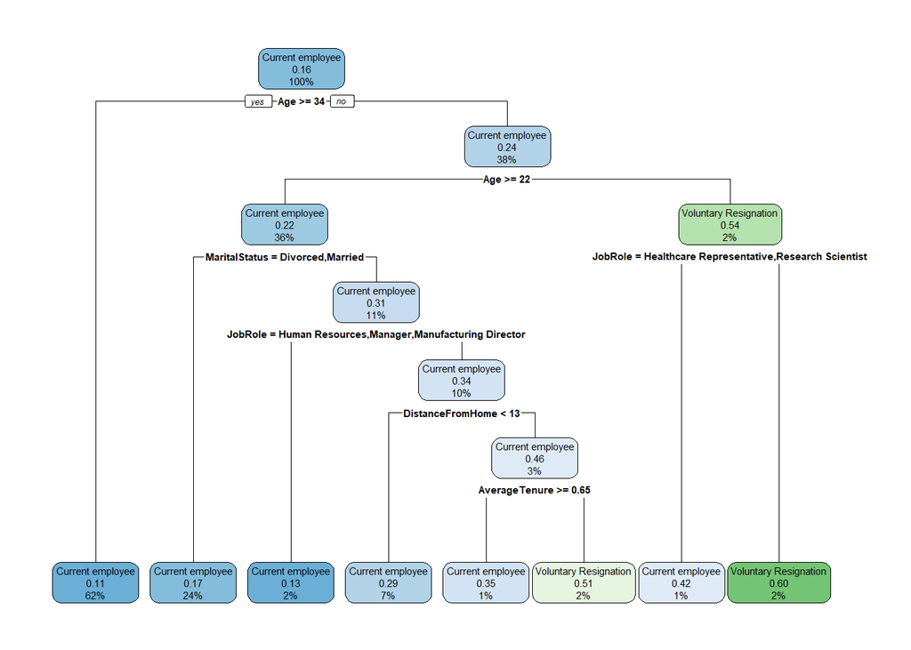

```r
rpart.plot(modelo_v5)
```

**Podemos concluir que pessoas com mais idade, acima de 34 anos, tem menos atrito no emprego e tem maior tendência de ficar na empresa.**